# Exploratory Subgroup Identification with ForestSearch

German Breast Cancer Study Group (GBSG) Analysis

Author

Larry F. León

Published

July 8, 2026

> **Method-general analysis.** The selection engine for the main analysis is set once via `fs_subgroup_method` in the setup chunk — `"consistency"` (default), `"dina"`, or `"grf"` (with `fs_grf_selection` = `"tree"`/`"frontier"`). The headline fit and every downstream step — full bootstrap, Tier-2 de-biased gate, cross-validation, leave-one-out, and the Kaplan–Meier band — inherit that engine from the single fitted object, so the whole analysis re-renders under a different method by changing one knob. The comparative DINA-screening, standalone-DINA, and GRF sections that follow are fixed illustrations of the individual engines and are unaffected by `fs_subgroup_method`.

## 0.1 Parallel Processing Configuration

ForestSearch supports parallel processing for computationally intensive operations (bootstrap, cross-validation).

```r
# Detect available cores (limited to 2 cores for CRAN checks)
n_cores_total <- parallel::detectCores()
n_cores <- max(1L, floor(0.80 * parallel::detectCores(logical = FALSE)))
cat("Using", n_cores, "of", n_cores_total, "total cores for parallel processing")
```

```
#> Using 11 of 14 total cores for parallel processing
```

```r
# Number of bootstrap iterations
# Use 500-2000 for production; reduced here for vignette
NB <- 1000

# ---------------------------------------------------------------------------
# Validation toggles (the slowest parts of the document).  Independent:
# run_cv  controls K-Fold cross-validation; run_loo controls leave-one-out
# (N-fold / OOB).  Either can be turned off without affecting the other.
# ---------------------------------------------------------------------------
run_cv  <- FALSE    # K-Fold cross-validation (kfold-cv + diagnostics)
run_loo <- FALSE    # Leave-one-out / N-fold OOB (oob-cv)
# 10-fold CV with multiple iterations
# Use Ksims >= 50 for production
Ksims <- 50

# Pre-seed CV/LOO timings so the Computational Timing table is well-formed
# whether or not these run (skipped analyses report NA).
timings$kfold <- NA_real_
timings$oob   <- NA_real_

# ---------------------------------------------------------------------------
# Per-analysis identification parameters (tune each analysis independently).
#   sg_focus      : which candidate subgroup the selection step chooses
#   hr_threshold  : harm/benefit floor on the HR scale
#   hr_consistency: minimum consistency rate (consistency search only)
# ---------------------------------------------------------------------------
# Main ForestSearch (consistency search)
fs_sg_focus              <- "effMaxSG"
fs_hr_threshold          <- 1.0
fs_hr_consistency        <- 1.0
fs_max_subgroups_search  <- 50

fs_conf_force <- c("er <= 0", "pgr <= 0")

fs_consistency_method    <- "resample"
# Tier-2 de-biased gate: a fast multiplier-bootstrap approximation of the
# bootstrap bias-correction, computed inside the fit and compared to the full
# bootstrap below.  It runs for whichever selection engine fs_subgroup_method
# names, de-biasing against that engine's own candidate family (it re-derives
# the per-candidate Cox dfbeta itself).
run_debias_gate <- TRUE     # add debias_gate = TRUE to the forestsearch call
gate_draws      <- 5000L    # multiplier-bootstrap draws for the gate

# ---------------------------------------------------------------------------
# Output directory for the Section 6.2 reproducibility payload written at the
# END of this document (manuscript Table + results overview).
#   NULL (default) -> alongside this .qmd, resolved at render time
#   or an explicit directory, e.g. "~/results" or "/abs/path/out"
results_dir <- NULL

# ---------------------------------------------------------------------------
# Selection engine for the MAIN analysis.  The headline fit, its bootstrap,
# the de-biased gate, CV/LOO, and the KM plot all flow from this single fit,
# so flipping subgroup_method re-runs the entire main analysis under that
# engine (each downstream step inherits the method from the fitted object):
#   "consistency" - the splitting-consistency search (default);
#   "dina"        - DINA performs selection (consistency search bypassed);
#   "grf"         - GRF performs selection (policy tree or DR-frontier).
# The Tier-2 gate de-biases against whichever engine's OWN candidate family,
# with re-selection matching that engine's selection rule.
# ---------------------------------------------------------------------------
fs_subgroup_method <- "consistency"  # "consistency" | "dina" | "grf"
fs_grf_selection   <- "frontier"      # only if fs_subgroup_method == "grf": "tree" | "frontier"
fs_grf_select_statistic <- "effect"       # only if subgroup_method=="grf" & grf_selection=="frontier": "dr" | "effect".
                                      #   "dr"     = native DR-score frontier winner;
                                      #   "effect" = re-rank the DR frontier on the inferential Cox HR (the
                                      #              statistic the Tier-2 gate de-biases).  No-op for the policy tree.
fs_grf_depth       <- 2L              # GRF depth (screening + GRF selection)
fs_dmin_grf        <- 4               # GRF DR-score screening floor
fs_dina_args       <- list()          # extra args forwarded to DINA selection
fs_dina_select_statistic <- "effect"    # only if subgroup_method=="dina": "dina" | "effect".
                                      #   "dina"   = native DINA tau-hat winner;
                                      #   "effect" = re-rank the DINA family on the inferential Cox HR (the
                                      #              statistic the Tier-2 gate de-biases).
# Tier-2 gate (main analysis): the gate's re-selection family for "dina"/"grf" is
# restricted to candidates competitive on the method's NATIVE statistic (DINA
# tau-hat / GRF DR-score).  NULL = use the recommended default, which matches the
# band to effect_neighborhood automatically (the band the engine selects within);
# give a number in (0, 1) to set the band explicitly, or >= 1 to de-bias against
# the full family.  Ignored for "consistency" (its maxcons re-selection already
# matches the search).
fs_family_native_nbhd <- NULL

# (A) ForestSearch + DINA screening (consistency search selects; DINA only
#     contributes candidate cuts)
dina_screen_sg_focus             <- "effMaxSG"
dina_screen_hr_threshold         <- 0.9
dina_screen_hr_consistency       <- 0.8
dina_screen_max_subgroups_search <- 30
# Screening cut set: FALSE => full DINA frontier; TRUE => only the single
# dina_subgroup()-selected cut (uses dina_screen_sg_focus / selection_rule).
dina_screen_selected_only        <- TRUE

# (C) ForestSearch subgroup_method = "dina" (DINA performs selection; the
#     consistency search is bypassed, so hr_consistency does not apply here).
#     The standalone DINA analysis (B) reuses these so (B) and (C) match.
fs_dina_sg_focus     <- "effMaxSG"
fs_dina_hr_threshold <- 0.90
# Tier-2 gate: the DINA re-selection family is restricted to candidates competitive
# on DINA's native tau-hat.  NULL = recommended default (matches effect_neighborhood
# automatically); set a number in (0, 1) for an explicit band, or >= 1 for the full
# family.  Note: this only tunes candidate competition -- the gate holds the forest
# fixed, so the full bootstrap stays the reference for DINA regardless.
fs_dina_family_native_nbhd <- NULL

# (D) ForestSearch subgroup_method = "grf" (GRF performs selection via a causal
#     forest policy tree or DR-score frontier; the consistency search, LASSO and
#     DINA are bypassed).  Dedicated demo: always runs GRF regardless of
#     fs_subgroup_method, mirroring the standalone DINA selection (C).
fs_grf_demo_selection     <- "frontier"  # "frontier" | "tree"
fs_grf_demo_depth         <- 2L          # GRF tree / DR-pair depth
fs_grf_demo_dmin          <- 0.0         # DR-score harm floor (0 = permissive default)
fs_grf_sg_focus           <- "effMaxSG"  # -> GRF frontier/tree selection rule
# Tier-2 gate: the GRF re-selection family is restricted to candidates competitive
# on GRF's native (RMST-based) DR-score.  NULL = recommended default (matches
# effect_neighborhood automatically); set a number in (0, 1) for an explicit band,
# or >= 1 for the full family.  Note: this only tunes candidate competition -- the
# gate holds the forest fixed, so the full bootstrap stays the reference for GRF
# regardless (a dominant DR-score winner can collapse the family to 1).
fs_grf_family_native_nbhd <- NULL
```

# 1 Introduction

This vignette demonstrates the **ForestSearch** methodology for exploratory subgroup identification in survival analysis, as described in León et al. (2024) *Statistics in Medicine*.

## 1.1 Motivation

In clinical trials, particularly oncology, subgroup analyses are essential for:

- Evaluating treatment effect consistency across patient populations
- Identifying subgroups where treatment may be detrimental (harm)
- Characterizing subgroups with enhanced benefit
- Informing regulatory decisions and clinical practice

While prespecified subgroups provide stronger evidence, important subgroups based on patient characteristics may not be anticipated. ForestSearch provides a principled approach to **exploratory** subgroup identification with proper statistical inference.

## 1.2 Methodology Overview

ForestSearch identifies subgroups through:

1. **Candidate factor selection**: Using LASSO and/or Generalized Random Forests (GRF)
2. **Exhaustive subgroup search**: Evaluating all combinations up to `maxk` factors
3. **Consistency-based selection**: Applying splitting consistency criteria
4. **Bootstrap bias correction**: Adjusting for selection-induced optimism
5. **Cross-validation**: Assessing algorithm stability

The key innovation is the **splitting consistency criterion**: a subgroup is considered “consistent with harm” if, when randomly split 50/50 many times, both halves consistently show hazard ratios ≥ 1.0 (for example if 1.0 represents a meaningful “harm threshold”).

# 2 Setup

## 2.1 Load Required Packages

```r
library(forestsearch)
library(survival)
library(data.table)
library(ggplot2)
library(gt)
library(grf)
library(policytree)
library(doFuture)
# Optional packages for enhanced output
library(patchwork)
library(weightedsurv)

# Set ggplot theme
theme_set(theme_minimal(base_size = 12))
```

# 3 Data: German Breast Cancer Study Group Trial

## 3.1 Study Background

The GBSG trial evaluated hormonal treatment (tamoxifen) versus chemotherapy in node-positive breast cancer patients. Key characteristics:

- **Sample size**: N = 686
- **Outcome**: Recurrence-free survival time
- **Censoring rate**: ~56%
- **Treatment**: Hormonal therapy (tamoxifen) vs. chemotherapy

## 3.2 Data Preparation

```r
# Load GBSG data (included in forestsearch package)
df.analysis <- gbsg

# Prepare analysis variables
df.analysis <- within(df.analysis, {
  id <- seq_len(nrow(df.analysis))
  time_months <- rfstime / 30.4375
  grade3 <- ifelse(grade == "3", 1, 0)
  treat <- hormon
})

# Define variable roles
confounders.name <- c("age", "meno", "size", "grade3", "nodes", "pgr", "er")
outcome.name <- "time_months"
event.name <- "status"
id.name <- "id"
treat.name <- "hormon"

# Display data structure
cat("Sample size:", nrow(df.analysis), "\n")
```

```
#> Sample size: 686
```

```r
cat("Events:", sum(df.analysis[[event.name]]),
    sprintf("(%.1f%%)\n", 100 * mean(df.analysis[[event.name]])))
```

```
#> Events: 299 (43.6%)
```

```r
cat("Baseline factors:", paste(confounders.name, collapse = ", "), "\n")
```

```
#> Baseline factors: age, meno, size, grade3, nodes, pgr, er
```

## 3.3 Baseline Characteristics

```r
create_summary_table(
  data = df.analysis,
  treat_var = treat.name,
  table_title = "GBSG Baseline Characteristics by Treatment Arm",
  vars_continuous = c("age", "nodes", "size", "er", "pgr"),
  vars_categorical = c("grade", "meno"),
  font_size = 12
)
```

GBSG Baseline Characteristics by Treatment Arm

| Characteristic |  | Control (n=440) | Treatment (n=246) | P-value<sup>1</sup> | SMD<sup>2</sup> |
| --- | --- | --- | --- | --- | --- |
| age | Mean (SD) | 51.1 (10.0) | 56.6 (9.4) | <0.001 | 0.57 |
| nodes | Mean (SD) | 4.9 (5.6) | 5.1 (5.3) | 0.665 | 0.03 |
| size | Mean (SD) | 29.6 (14.4) | 28.8 (14.1) | 0.470 | 0.06 |
| er | Mean (SD) | 79.7 (124.2) | 125.8 (191.1) | <0.001 | 0.30 |
| pgr | Mean (SD) | 102.0 (170.0) | 124.3 (249.7) | 0.213 | 0.11 |
| grade |  |  |  | 0.273 | 0.06 |
|  | 1 | 48 (10.9%) | 33 (13.4%) |  |  |
|  | 2 | 281 (63.9%) | 163 (66.3%) |  |  |
|  | 3 | 111 (25.2%) | 50 (20.3%) |  |  |
| meno |  | 209 (47.5%) | 187 (76.0%) | <0.001 | 0.61 |

<sup>1</sup> P-values: t-test for continuous, chi-square/Fisher's exact for categorical/binary variables  
<sup>2</sup> SMD = Standardized mean difference (Cohen's d for continuous, Cramer's V for categorical)

## 3.4 Kaplan-Meier Analysis (ITT Population)

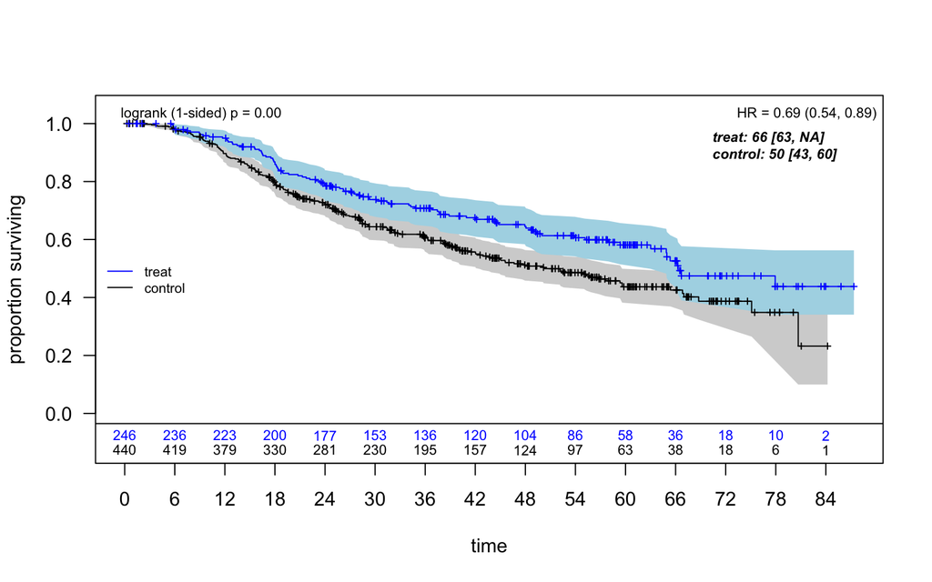

```r
# Prepare counting process data for KM plot
dfcount <- df_counting(
  df = df.analysis,
  by.risk = 6,
  tte.name = outcome.name,
  event.name = event.name,
  treat.name = treat.name
)

# Plot with confidence intervals and log-rank test
plot_weighted_km(
  dfcount,
  conf.int = TRUE,
  show.logrank = TRUE,
  ymax = 1.05,
  xmed.fraction = 0.775,
  ymed.offset = 0.125
)
```

The ITT Cox hazard ratio estimate is approximately 0.69 (95% CI: 0.54, 0.89), suggesting an overall benefit for hormonal therapy.

# 4 Preliminary Analysis: Generalized Random Forests

Before running ForestSearch, we can use GRF to explore potential treatment effect heterogeneity and identify candidate factors.

```r
t0 <- proc.time()

grf_est <- grf.subg.harm.survival(
  data = df.analysis,
  confounders.name = confounders.name,
  outcome.name = outcome.name,
  event.name = event.name,
  id.name = id.name,
  treat.name = treat.name,
  maxdepth = 2,
  n.min = 60,
  dmin.grf = 12,
  frac.tau = 0.60,
  details = TRUE,
  return_selected_cuts_only = FALSE
)
```

```
#> tau, maxdepth = 46.75811 2
#>    leaf.node control.mean control.size control.se depth
#> 1          2         6.49        82.00       3.34     1
#> 2          3        -4.10       604.00       1.06     1
#> 11         4        -7.90       112.00       2.81     2
#> 21         5         3.85       177.00       1.87     2
#> 4          7        -5.89       356.00       1.33     2
#>
#> Selected subgroup:
#>   leaf.node control.mean control.size control.se depth
#> 1         2         6.49        82.00       3.34     1
#>
#> GRF subgroup found
#> Terminating node at max.diff (sg.harm.id):
#> [1] "er <= 0"
#>
#> All splits (from all trees):
#> [1] "er <= 0"   "age <= 50" "age <= 43"
```

```r
timings$grf <- (proc.time() - t0)["elapsed"]
```

```r
# Display policy trees
# leaf1 = recommend control, leaf2 = recommend treatment
oldpar <- par(mfrow = c(1, 2))
plot(grf_est$tree1, leaf.labels = c("Control", "Treat"), main = "Depth 1")
```

[interactive chart not shown]

```r
plot(grf_est$tree2, leaf.labels = c("Control", "Treat"), main = "Depth 2")
```

[interactive chart not shown]

```r
par(oldpar)
```

GRF identifies estrogen receptor status (ER) as a key factor, with ER ≤ 0 suggesting potential harm from hormonal therapy.

# 5 ForestSearch Analysis

## 5.1 Running ForestSearch

The selection engine for this main analysis is set by `fs_subgroup_method` in the setup chunk (`"consistency"`, `"dina"`, or `"grf"` with `fs_grf_selection`). Everything downstream — the full bootstrap, the Tier-2 de-biased gate, the cross-validation/leave-one-out diagnostics, and the Kaplan–Meier band — runs off the single fitted object and therefore inherits that engine automatically, so the entire analysis re-renders under a different method by changing one knob. The consistency search (the default below) performs an exhaustive search over candidate subgroup combinations with up to `maxk` factors; the parameters in the table apply to that engine. Key parameters:

[output not shown]

**NoteSelection criteria (`sg_focus`)**

- `"hr"` – highest consistency, then largest effect.
- `"minSG"` – smallest passing subgroup, ties broken by consistency.
- `"hrMaxSG"` – among candidates whose effect is within `effect_neighborhood` (default 10%) of the maximum, pick the *largest* sample size.
- `"hrMinSG"` – among candidates within `effect_neighborhood` of the maximum effect, pick the *smallest* sample size.

`"hrMaxSG"` and `"hrMinSG"` use a *lexicographic-with-tolerance* rule: effect size is primary, but a small relative loss in effect is accepted to optimize sample size. Setting `effect_neighborhood = 0` reduces these to a strict max-effect filter. For GLM ratio measures (OR, IRR), the neighborhood test is applied on the natural scale.

```
#>
#> [forestsearch] Subgroup Identification Configuration
#>   Outcome type:   survival (Cox PH)
#>   Effect measure: HR (hazard ratio)
#>   Scale:          log (ratio)
#>
#>   Screening:      HR >= 1.00  (log: 0.0000)
#>   Consistency:    HR >= 1.00  (log: 0.0000)
#>   Consistency rate threshold: 90%
#>
#>   Interpretation:
#>     Candidates: subgroup hazard ratio >= 1.00
#>     Splits:     each split HR >= 1.00
```

```
#>   Search Alignment Diagnostic
```

```
#>
#>   Outcome:    time_months (survival)
```

```
#>   Treatment:  hormon
```

```
#>   Measure:    Hazard Ratio (HR)
```

```
#>
#>   ForestSearch searches for:
#>     Subgroups where hormon increases the event hazard
#>     (HR >= threshold in the candidate subgroup)
```

```
#>
#>   Thresholds:
#>     Screening: HR >= 1.000 in the candidate subgroup
#>     Consistency: HR >= 1.000 in each bootstrap split
```

```
#>
#>   Variable screening:
```

```
#>     LASSO: LASSO screening: DISABLED
```

```
#>     GRF:   DISABLED
```

```
#>
#>   No alignment concerns detected.
```

```
#> Forced confounders: er <= 0, pgr <= 0
#> J-quantile cuts: er (J=10), pgr (J=10)
#> Candidate factors: 33
#>  [1] "er <= 0"    "pgr <= 0"   "er <= 3"    "er <= 9"    "er <= 17"
#>  [6] "er <= 30"   "er <= 44"   "er <= 70"   "er <= 100"  "er <= 174"
#> [11] "er <= 294"  "pgr <= 2"   "pgr <= 8"   "pgr <= 16"  "pgr <= 26"
#> [16] "pgr <= 45"  "pgr <= 77"  "pgr <= 114" "pgr <= 184" "pgr <= 337"
#> [21] "age <= 53"  "age <= 46"  "age <= 61"  "size <= 29" "size <= 25"
#> [26] "size <= 20" "size <= 35" "nodes <= 5" "nodes <= 3" "nodes <= 1"
#> [31] "nodes <= 7" "meno"       "grade3"
#> Number of possible configurations (<= maxk): maxk = 2 , # combinations = 2211
#> Per-arm events criteria: control >= 10, treatment >= 10
#> Sample size criteria: n >= 60
#> Subgroup search completed in 0.05 minutes
#>
#> --- Filtering Summary ---
#>   Combinations evaluated: 2211
#>   Passed variance check: 2069
#>   Passed prevalence (>= 0.025 ): 2069
#>   Passed redundancy check: 1943
#>   Passed events counts (d0>= 10, d1>= 10): 1451
#>   Passed sample size (n>= 60 ): 1407
#>   Cox model fit successfully: 1407
#>   Passed effect threshold (effect >= 1.0000): 124
#> -------------------------
#>
#> Found 124 subgroup candidate(s)
#> # of candidate subgroups (meeting all criteria) = 124
#> Removed 1 near-duplicate subgroups
#> # of unique initial candidates: 123
#> # Restricting to top stop_Kgroups = 50
#> # of candidates to evaluate: 50
#>
#> ==============================================================================================================
#> CANDIDATE EVALUATION PREVIEW (pre-consistency) (sg_focus = "hrMaxSG", selection_rule = "neighborhood")
#> ==============================================================================================================
#> Rank  HR      N      E     K    OF  IB  Subgroup
#> --------------------------------------------------------------------------------------------------------------
#>    1   2.537     61    34    2  *   *   {er <= 0} & {size <= 35}
#>    2   2.335     61    31    2  -   *   {er <= 0} & {nodes <= 7}
```

[output cut: 37 more lines]

```
#>   40   1.022    128    73    1  -   -   {er <= 3}
#>   41   1.022    128    73    2  -   -   {er <= 100} & {er <= 3}
#>   42   1.016    124    78    2  -   -   !{size <= 29} & !{nodes <= 5}
#>   43   1.255    123    73    2  -   -   !{size <= 25} & {er <= 17}
#>   44   1.139    123    66    2  -   -   {grade3} & {pgr <= 26}
#>   45   1.118    123    63    2  -   -   !{meno} & {er <= 17}
#>   46   1.113    122    70    2  -   -   {er <= 3} & {pgr <= 77}
#>   47   1.102    120    69    2  -   -   {er <= 3} & {pgr <= 26}
#>   48   1.027    120    60    2  -   -   {grade3} & {er <= 44}
#>   49   1.019    120    67    2  -   -   !{size <= 35} & {pgr <= 184}
#>   50   1.056    115    69    2  -   -   {pgr <= 2} & {er <= 70}
#> --------------------------------------------------------------------------------------------------------------
#> To evaluate: 50   On frontier: 14   In band: 2
#> Legend: OF = on Pareto frontier;  IB = in effect-size band.
#> ==============================================================================================================
```

```
#> Parallel plan: multisession with 11 workers.
```

```
#> Parallel config: workers = 11 , batch_size = 22
#> Batch 1 / 3 : candidates 1 - 22
#> Batch 2 / 3 : candidates 23 - 44
#> Batch 3 / 3 : candidates 45 - 50
#> Evaluated 50 of 50 candidates (complete)
#> 4 subgroups passed consistency threshold
```

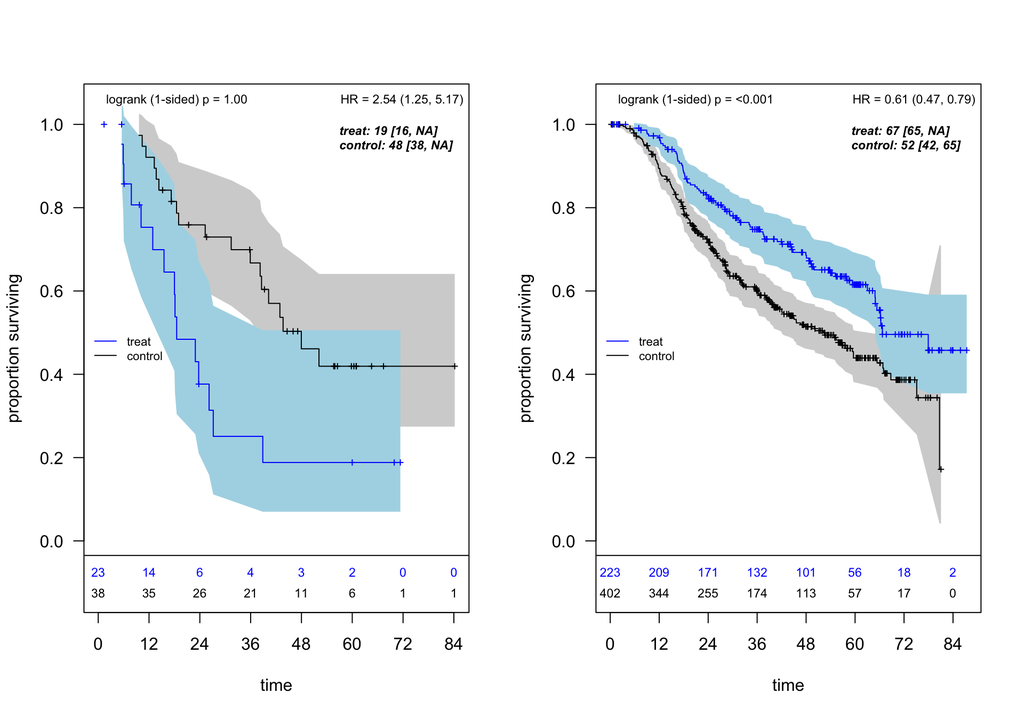

```
#> *** Subgroup found: {er <= 0} {size <= 35}
#> % consistency criteria met= 0.99
#> SG focus = hrMaxSG
#>
#> ==============================================================================================================
#> CANDIDATE EVALUATION SUMMARY  (sg_focus = "hrMaxSG", selection_rule = "neighborhood")
#> ==============================================================================================================
#> Rank  HR      N      E     K    P      OF  IB  S  Subgroup
#> --------------------------------------------------------------------------------------------------------------
#>    1   2.537     61    34    2  0.990  *   *   *  {er <= 0} & {size <= 35}
#>    2   2.335     61    31    2  0.970  -   *   -  {er <= 0} & {nodes <= 7}
#>    3   1.951     82    45    1  0.960  *   -   -  {er <= 0}
#>    4   2.222     75    41    2  0.990  *   -   -  {er <= 0} & {pgr <= 26}
#> --------------------------------------------------------------------------------------------------------------
#> Evaluated: 50   Passed: 4   On frontier: 3   In band: 2   Selected: m=1
#> Legend: P = Pcons (consistency probability); OF = on Pareto frontier;  IB = in effect-size band; S = selected.
#> ==============================================================================================================
#>
#> Seconds and minutes forestsearch overall = 4.414 0.0736
#> Consistency algorithm used: twostage
#> Subgroup identified: {er <= 0} & {size <= 35}
#> De-biased gate: HR = 1.449 (gate point 1.00) -> consistent with harm
```

```r
t0 <- proc.time()

fs <- forestsearch(
  # --- Required data + roles ----------------------------------------------
  df.analysis,
  outcome.name              = outcome.name,
  event.name                = event.name,
  treat.name                = treat.name,
  id.name                   = id.name,
  confounders.name          = confounders.name,
  potentialOutcome.name     = NULL,           # default NULL
  flag_harm.name            = NULL,           # default NULL
  df.predict                = NULL,           # default NULL
  df.test                   = NULL,           # default NULL
  is.RCT                    = TRUE,           # default TRUE
  seedit                    = 8316951,        # default 8316951
  est.scale                 = "hr",           # default "hr"
  # --- Screening engines (candidate generation) ---------------------------
  use_lasso                 = FALSE,           # default TRUE
  use_grf                   = FALSE,           # default TRUE
  grf_res                   = NULL,           # default NULL
  grf_cuts                  = NULL,           # default NULL
  grf_depth                 = fs_grf_depth,   # set in setup chunk (default 2)
  dmin.grf                  = fs_dmin_grf,     # set in setup chunk (default 0.0)
  frac.tau                  = 0.80,           # default 0.8
  vi.grf.min                = -0.2,           # default -0.2
  return_selected_cuts_only = TRUE,           # default TRUE
  tune_grf                  = FALSE,          # default FALSE
  use_dina                  = FALSE,          # default FALSE
  dina_res                  = NULL,           # default NULL
  dina_cuts                 = NULL,           # default NULL
  dina_args                 = fs_dina_args,   # extra DINA tuning (setup chunk)
  # --- Candidate-cut construction -----------------------------------------
  max_n_confounders         = 1000,           # default 1000
  conf_force                = fs_conf_force,           # default NULL
  defaultcut_names          = NULL,           # default NULL
  cut_type                  = "default",      # default "default"
  exclude_cuts              = NULL,           # default NULL
  replace_med_grf           = FALSE,          # default FALSE
  cont.cutoff               = 4,              # default 4
  conf.cont_medians         = NULL,           # default NULL
  conf.cont_medians_force   = NULL,           # default NULL
  conf.cont_jcuts           = list(er = 10, pgr = 10),           # default NULL
  collapse_cuts = TRUE,
  # --- Selection engine ---------------------------------------------------
  subgroup_method           = fs_subgroup_method,  # set in setup chunk: consistency | dina | grf
  grf_selection             = fs_grf_selection,    # set in setup chunk (used when subgroup_method = "grf")
  grf_select_statistic      = fs_grf_select_statistic,  # set in setup chunk (frontier only)
  dina_select_statistic     = fs_dina_select_statistic,  # set in setup chunk (used when subgroup_method = "dina")
  sg_focus                  = fs_sg_focus,         # set in setup chunk
  selection_rule            = "neighborhood",  # default "neighborhood"
  effect_neighborhood       = 0.10,            # default 0.10
  # --- Tier-2 de-biased gate ----------------------------------------------
  debias_gate               = run_debias_gate,           # set in setup chunk
  debias_gate_args          = list(draws = gate_draws,
                                   family_native_neighborhood = fs_family_native_nbhd),
  # --- Subgroup constraints -----------------------------------------------
  n.min                     = 60,                       # default 60
  d0.min                    = 10,                       # default 10
  d1.min                    = 10,                       # default 10
  maxk                      = 2,                        # default 2
  max_subgroups_search      = fs_max_subgroups_search,  # set in setup chunk
  # --- Thresholds (survival / HR scale) -----------------------------------
  hr.threshold              = fs_hr_threshold,    # set in setup chunk
  hr.consistency            = fs_hr_consistency,  # set in setup chunk
  effect.threshold          = NULL,           # default NULL (alias of hr.threshold)
  consistency.threshold     = NULL,           # default NULL (alias of hr.consistency)
  pconsistency.threshold    = 0.90,           # default 0.90
  consistency_method        = fs_consistency_method,
  m1.threshold              = Inf,            # default Inf
  minp                      = 0.025,          # default 0.025
  # --- Consistency search -------------------------------------------------
  fs.splits                 = 1000,           # default 1000
  stop_threshold            = 0.95,           # default 0.95
  use_twostage              = TRUE,           # default TRUE
  twostage_args             = list(),         # default list()
  max.minutes               = 3,              # default 3
  # --- Output / diagnostics -----------------------------------------------
  show_candidate_summary    = TRUE,           # default FALSE
  details                   = TRUE,           # default FALSE
  quiet                     = FALSE,          # default FALSE
  by.risk                   = 12,             # default 12
  plot.sg                   = TRUE,           # default FALSE
  plot.grf                  = FALSE,          # default FALSE
  # --- Parallel -----------------------------------------------------------
  parallel_args = list(
    plan = "multisession",
    workers = n_cores,
    show_message = TRUE
  )
)
```

```r
plan("sequential")
timings$forestsearch <- (proc.time() - t0)["elapsed"]

cat("\nForestSearch completed in",
    round(timings$forestsearch, 1), "seconds\n")
```

```
#>
#> ForestSearch completed in 7 seconds
```

## 5.2 ForestSearch Results

### 5.2.1 Identified Subgroups

```r
# Generate results tables
res_tabs <- sg_tables(fs, ndecimals = 3, which_df = "est")

# Display top subgroups meeting criteria
res_tabs$sg10_out
```

**Identified Subgroups**

Two-factor subgroups (maxk=2)

| Factor 1 | Factor 2 | N | Events | E<sub>1</sub> | HR | P<sub>cons</sub> |
| --- | --- | --- | --- | --- | --- | --- |
| {er <= 0} | {size <= 35} | 61 | 34 | 15 | 2.537 | 0.990 |
| {er <= 0} | {nodes <= 7} | 61 | 31 | 11 | 2.335 | 0.970 |
| {er <= 0} |  | 82 | 45 | 16 | 1.951 | 0.960 |
| {er <= 0} | {pgr <= 26} | 75 | 41 | 16 | 2.222 | 0.990 |

**Search Configuration:** Single-factor candidates (L) = 66; Maximum combinations evaluated = 2,211; Search depth (maxk) = 2  
**Search Results:** Candidate subgroups found = 124; Maximum HR estimate = 2.54  
**Note:** E<sub>1</sub> = events in treatment arm; P<sub>cons</sub> = consistency proportion

### 5.2.2 Treatment Effect Estimates

```r
# ITT and subgroup estimates
res_tabs$tab_estimates
```

**Treatment Effect Estimates**

Training data estimates

| Subgroup | n | n1 | events | m1 | m0 | RMST | HR (95% CI) |
| --- | --- | --- | --- | --- | --- | --- | --- |
| ITT | 686 (100.0%) | 246 (35.9%) | 299 (43.6%) | 66.3 | 50.2 | 7.8 | 0.69 (0.54, 0.89) |
| Questionable<sup>1</sup> | 61 (8.9%) | 23 (37.7%) | 34 (55.7%) | 18.5 | 48 | -19 | 2.54 (1.25, 5.17) |
| Recommend | 625 (91.1%) | 223 (35.7%) | 265 (42.4%) | 66.7 | 52.2 | 9.6 | 0.61 (0.47, 0.79) |

<sup>1</sup> **Identified subgroup:** {er <= 0} & {size <= 35}

### 5.2.3 Identified Subgroup Definition

```r
cat("Identified subgroup (H):", paste(fs$sg.harm, collapse = " & "), "\n")
```

```
#> Identified subgroup (H): {er <= 0} & {size <= 35}
```

```r
cat("Subgroup size:", sum(fs$df.est$treat.recommend == 0),
    sprintf("(%.1f%% of ITT)\n",
            100 * mean(fs$df.est$treat.recommend == 0)))
```

```
#> Subgroup size: 61 (8.9% of ITT)
```

### 5.2.4 Selection Diagnostic: Pareto Frontier

Beyond the single subgroup chosen by `sg_focus`, it is often informative to inspect the *Pareto frontier* on (effect, N) – the set of candidate subgroups that are not dominated on both axes simultaneously. A candidate is dominated when another candidate has at least as large an effect *and* at least as large a sample size, with at least one strict inequality. The frontier is a post-hoc diagnostic that lists genuine trade-off alternatives to the selected subgroup; it does **not** affect selection.

For `"hrMinSG"` the selected subgroup may not appear on the frontier – that focus deliberately prefers small subgroups, which can be N-dominated by their larger neighbors.

```r
# Formatted gt table; selected subgroup is highlighted and marked with ★.
# Works uniformly for survival (HR) and GLM (OR, RR, IRR, RD, IRD, MD)
# outcomes -- effect column label and scale derived from fs$effect_measure.
pareto_frontier_table(fs)
```

Pareto frontier on (HR, N)

3 non-dominated candidate(s) | sg_focus = 'hrMaxSG' | HR shown on natural scale | diagnostic only

| S<sup>1,2</sup> | M.1 | M.2 | N | E | HR | P<sup>3</sup> | K |
| --- | --- | --- | --- | --- | --- | --- | --- |
| ★ | {er <= 0} | {size <= 35} | 61 | 34 | 2.54 | 0.99 | 2 |
|  | {er <= 0} | {pgr <= 26} | 75 | 41 | 2.22 | 0.99 | 2 |
|  | {er <= 0} |  | 82 | 45 | 1.95 | 0.96 | 1 |

<sup>1</sup> S: selected subgroup (winner of the configured selection rule).  
<sup>2</sup> ★ marks the subgroup chosen by sg_focus = 'hrMaxSG'.  
<sup>3</sup> P: Pcons (consistency probability).

```r
# Programmatic access (effect on natural scale, plus is_selected flag):
pareto_frontier_table(fs, format = "data.table")
```

### 5.2.5 Agreement with GRF

ForestSearch and GRF identify subgroups by different mechanisms – FS via exhaustive search with consistency filtering, GRF via causal survival forests plus policy trees – so agreement on subject-level membership provides an informal robustness check. `compare_fs_subgroups()` produces a publication-ready cross-tabulation plus Cohen’s kappa; it accepts forestsearch and GRF result objects directly, and handles non-detection (method identifies no subgroup) by assigning all subjects to the complement.

```r
sg_compare <- compare_fs_subgroups(
  fs1               = fs,
  fs2               = grf_est,
  label1            = "ForestSearch",
  label2            = "GRF Standalone",
  id.name           = id.name,
  subgroup_notation = "harm",
  title             = "FS vs GRF: Subgroup Membership Concordance",
  subtitle          = "GBSG observed data (Cox, harm search)",
  font_size         = 13
)
sg_compare$table
```

**FS vs GRF: Subgroup Membership Concordance**

GBSG observed data (Cox, harm search)

| ForestSearch | GRF Standalone H (Questionable) | GRF Standalone Hᶜ (Recommend) | Total |  |
| --- | --- | --- | --- | --- |
| H (Questionable) | 61 | 0 |  | 61 |
| Hᶜ (Recommend) | 21 | 604 | 625 |  |
| Total | 82 | 604 | 686 |  |

**Agreement:** 665 / 686 (96.9%) **Cohen’s κ:** 0.836 **ForestSearch H:** {er <= 0} & {size <= 35} **GRF Standalone H:** er <= 0

```r
cat("Concordance statistics:\n")
```

```
#> Concordance statistics:
```

```r
cat(sprintf("  Agreement:       %.1f%%\n",
    100 * sg_compare$concordance$agreement))
```

```
#>   Agreement:       96.9%
```

```r
cat(sprintf("  Cohen's kappa:   %.3f\n",
    sg_compare$concordance$kappa))
```

```
#>   Cohen's kappa:   0.836
```

```r
cat(sprintf("  Concordant:      %d / Discordant: %d / Total: %d\n",
    sg_compare$concordance$n_agree,
    sg_compare$concordance$n_disagree,
    sg_compare$concordance$n_total))
```

```
#>   Concordant:      665 / Discordant: 21 / Total: 686
```

# 6 Bootstrap Bias Correction

## 6.1 Rationale

Cox model estimates from identified subgroups are **upwardly biased** due to the selection process (subgroups are selected *because* they show extreme effects). Bootstrap bias correction addresses this by:

1. Resampling with replacement
2. Re-running the entire ForestSearch algorithm
3. Computing bias terms from bootstrap vs. observed estimates
4. Applying infinitesimal jackknife variance estimation

## 6.2 Running Bootstrap Analysis

```r
t0 <- proc.time()

fs_bc <- forestsearch_bootstrap_dofuture(
  fs.est = fs,
  nb_boots = NB,
  show_three = FALSE,
  details = FALSE,
  parallel_args = list(
    plan = "multisession",
    workers = n_cores,
    show_message = TRUE
  )
)
```

```
#> Bootstrap parallel config: Using user-provided settings
```

```
#> System max cores available: 14
```

```
#> Bootstrap will use: 11 workers with 'multisession' plan
```

```
#> Parallel plan: multisession with 11 workers.
```

```
#> Bootstrap iteration 1/1000
```

```
#> Bootstrap iteration 10/1000
```

```
#> Bootstrap iteration 50/1000
```

```
#> Bootstrap iteration 100/1000
```

```
#> Bootstrap iteration 250/1000
```

```
#> Bootstrap iteration 500/1000
```

```
#> Bootstrap iteration 750/1000
```

```
#> Bootstrap iteration 1000/1000
```

```r
plan("sequential")
timings$bootstrap <- (proc.time() - t0)["elapsed"]

cat("\nBootstrap completed in",
    round(timings$bootstrap / 60, 1), "minutes\n")
```

```
#>
#> Bootstrap completed in 12.6 minutes
```

## 6.3 Bootstrap Summary and Diagnostics

```r
# Comprehensive summary with diagnostics
summaries <- summarize_bootstrap_results(
  sgharm = fs$sg.harm,
  boot_results = fs_bc,
  create_plots = TRUE,
  est.scale = "hr"
)
```

```
#>
#> ===============================================================
#>            BOOTSTRAP ANALYSIS SUMMARY
#> ===============================================================
#>
#> IDENTIFIED SUBGROUP:
#> -------------------------------------------------------------
#>   H: {er <= 0} & {size <= 35}
#>
#> BOOTSTRAP SUCCESS METRICS:
#> -------------------------------------------------------------
#>   Total iterations:              1000
#>   Successful subgroup ID:        976 (97.6%)
#>   Failed to find subgroup:       24 (2.4%)
#>
#> TIMING ANALYSIS:
#> -------------------------------------------------------------
#> Overall:
#>   Total bootstrap time:          12.57 minutes (0.21 hours)
#>   Average per iteration:         0.01 min (0.8 sec)
```

```r
# Display bias-corrected estimates table
summaries$table
```

**Treatment Effect by Subgroup**

Bootstrap bias-corrected estimates (1000 iterations)

| Subgroup | Sample Size N | Sample Size N<sub>T</sub> | Sample Size Events | Survival Med<sub>T</sub> | Survival Med<sub>C</sub> | Survival RMST<sub>d</sub> | Treatment Effect HR (95% CI)†<sup>1</sup> | Treatment Effect HR‡ (95% CI)<sup>2</sup> |
| --- | --- | --- | --- | --- | --- | --- | --- | --- |
| Qstnbl<sup>3</sup> | 61 (8.9%) | 23 (37.7%) | 34 (55.7%) | 18.5 | 48 | -19 | 2.54 (1.25, 5.17) | 1.94 (0.89,4.21) |
| Recmnd | 625 (91.1%) | 223 (35.7%) | 265 (42.4%) | 66.7 | 52.2 | 9.6 | 0.61 (0.47, 0.79) | 0.63 (0.43,0.93) |

<sup>1</sup> **Unadjusted HR**: Standard Cox regression hazard ratio with robust standard errors  
<sup>2</sup> **Bias-corrected HR**: Bootstrap-adjusted estimate using infinitesimal jackknife method (1000 iterations). Corrects for optimism in subgroup selection.  
<sup>3</sup> **Identified subgroup**: {er <= 0} & {size <= 35}  
*Note*: Med = Median survival time (months). RMST<sub>d</sub> = Restricted mean survival time difference. Subgroup identified in 97.6% of bootstrap samples.

## 6.4 Fast de-biased gate vs. full bootstrap

The Tier-2 de-biased gate is a fast multiplier-bootstrap approximation of the bootstrap bias-correction. It reuses per-candidate Cox influence (`dfbeta`) over the selection engine’s **own** candidate family — the enumerated consistency candidates, DINA’s qualifying cuts, or GRF’s DR-score frontier, depending on `fs_subgroup_method` — and re-selects under multiplier draws, so its selection-bias term mirrors the same search optimism the full bootstrap corrects — without re-running the search per resample. The table below compares the gate (computed inside the fit) against the full bootstrap from the previous section. The naive-HR row is a scale sanity check; agreement on the de-biased row is the Tier-2-vs-Tier-1 validation. By default the de-biased CI uses the same infinitesimal-jackknife variance as the full bootstrap (the `ci_method = 'ij'` default), so the de-biased row compares both point estimate and interval like-for-like. The gate de-biases both the selected subgroup and its complement, so both appear in the comparison and the table below.

Selected subgroup: {er <= 0} & {size <= 35} (complement = remaining subjects)

| quantity | Tier 2 (gate) | Tier 1 (bootstrap) |
| --- | --- | --- |
| naive HR (95% CI) | 2.537 (1.245, 5.168) | 2.537 (1.245, 5.168) |
| de-biased HR (95% CI) | 1.449 (0.622, 3.373) | 1.935 (0.890, 4.211) |
| complement naive HR (95% CI) | 0.608 (0.469, 0.789) | 0.608 (0.469, 0.789) |
| complement de-biased HR (95% CI) | 0.645 (0.402, 1.033) | 0.630 (0.427, 0.930) |

Scale cross-check (naive gate vs bootstrap H0): **PASS** (2.537 vs 2.537).

Candidate family: 1744 (full <= maxk space); screened survivors = 124.

Re-selection rule = `effMaxSG` (matches the consistency search statistic).

Timing: Tier 1 bootstrap (1000 boots) 754.9 s (12.6 min); Tier 2 gate 0.34 s -> **2194x** faster (multiplier loop only; the full bootstrap scales with `NB`, the gate does not).

Gate `harm_flag_debiased` = **TRUE** (de-biased HR 1.449 vs gate 1.00); selection bias 0.5556 (log-HR). De-biased CI: infinitesimal jackknife (Tier-1 analogue) (IJ SE 0.431 vs robust SE 0.363, log-HR). Complement (n = 625): naive HR 0.608 -> de-biased 0.645 (selection bias -0.0552, log-HR).

The same bias-corrected estimates table, rebuilt from the Tier-2 gate object. The descriptive columns and naive effect are tier-independent (inherited from the bootstrap result used as a template); the bias-corrected column carries the gate’s de-biased estimate for **both** the selected subgroup and its complement.

```r
gate_estimates_table(fs, boot_results = fs_bc, est.scale = "hr", digits = 2)
```

**Treatment Effect by Subgroup**

Tier-2 de-biased estimate (multiplier bootstrap, 5000 draws)

| Subgroup | Sample Size N | Sample Size N<sub>T</sub> | Sample Size Events | Survival Med<sub>T</sub> | Survival Med<sub>C</sub> | Survival RMST<sub>d</sub> | Treatment Effect HR (95% CI)†<sup>1</sup> | Treatment Effect HR‡ (95% CI)<sup>2</sup> |
| --- | --- | --- | --- | --- | --- | --- | --- | --- |
| Qstnbl<sup>3</sup> | 61 (8.9%) | 23 (37.7%) | 34 (55.7%) | 18.5 | 48 | -19 | 2.54 (1.25, 5.17) | 1.45 (0.62,3.37) |
| Recmnd | 625 (91.1%) | 223 (35.7%) | 265 (42.4%) | 66.7 | 52.2 | 9.6 | 0.61 (0.47, 0.79) | 0.64 (0.40,1.03) |

<sup>1</sup> **Unadjusted HR**: Standard Cox regression hazard ratio with robust standard errors  
<sup>2</sup> **Bias-corrected HR**: Bootstrap-adjusted estimate using infinitesimal jackknife method (5000 iterations). Corrects for optimism in subgroup selection.  
<sup>3</sup> **Identified subgroup**: {er <= 0} & {size <= 35}  
*Note*: Med = Median survival time (months). RMST<sub>d</sub> = Restricted mean survival time difference.

## 6.5 Kaplan-Meier by Identified Subgroups

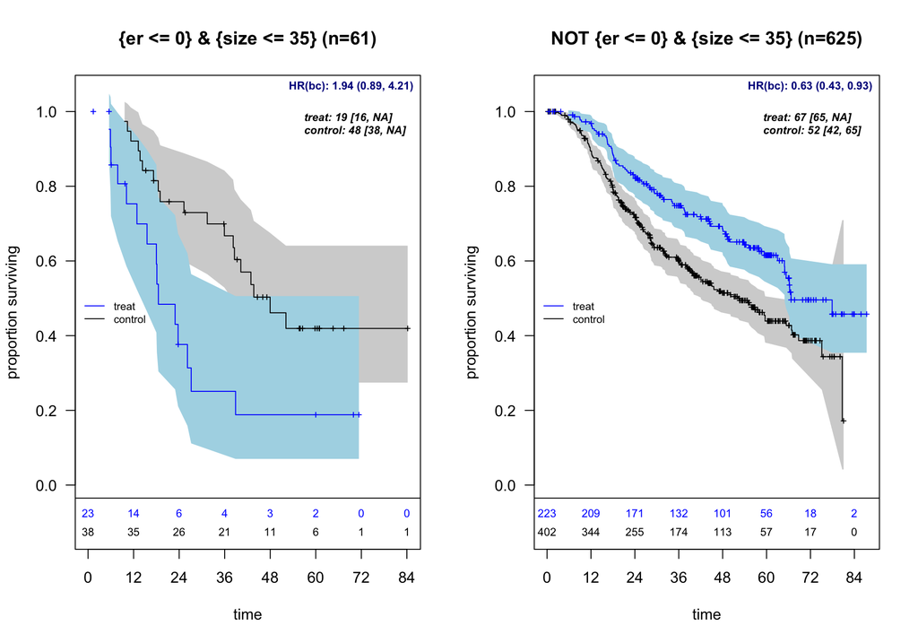

Kaplan-Meier survival curves by identified subgroup

```r
km_result <- plot_sg_weighted_km(
  fs.est = fs,
  outcome.name = "time_months",
  event.name = "status",
  treat.name = "hormon",
  show.logrank = FALSE,
  conf.int = TRUE,
  by.risk = 12,
  show.cox = FALSE, show.cox.bc = TRUE,
  fs_bc = fs_bc,
  hr_bc_position = "topright"
)
```

**Note**

**Note:** Identified subgroup: {er <= 0} & {size <= 35}. HR(bc) = bootstrap bias-corrected hazard ratio. Medians [95% CI] for arms are un-adjusted.

### 6.5.1 Event Count Summary

Low event counts can lead to unstable HR estimates. This summary helps identify potential issues:

```r
event_summary <- summarize_bootstrap_events(fs_bc, threshold = 10)
```

```
#>
#> === Bootstrap Event Count Summary ===
#> Total bootstrap iterations: 1000
#> Event threshold: <10 events
#>
#> ORIGINAL Subgroup H on BOOTSTRAP samples:
#>   Control arm <10 events: 0 (0.0%)
#>   Treatment arm <10 events: 0 (0.0%)
#>   Either arm <10 events: 0 (0.0%)
#>
#> ORIGINAL Subgroup Hc on BOOTSTRAP samples:
#>   Control arm <10 events: 0 (0.0%)
#>   Treatment arm <10 events: 0 (0.0%)
#>   Either arm <10 events: 0 (0.0%)
#>
#> NEW Subgroups found: 976 (97.6%)
#>
#> NEW Subgroup H* on ORIGINAL data:
#>   Control arm <10 events: 0 (0.0% of successful)
#>   Treatment arm <10 events: 0 (0.0% of successful)
#>   Either arm <10 events: 0 (0.0% of successful)
#>
#> NEW Subgroup Hc* on ORIGINAL data:
#>   Control arm <10 events: 0 (0.0% of successful)
#>   Treatment arm <10 events: 0 (0.0% of successful)
#>   Either arm <10 events: 0 (0.0% of successful)
```

### 6.5.2 Bootstrap Diagnostics

```r
# Quality metrics
summaries$diagnostics_table_gt
```

**Bootstrap Diagnostics Summary**

Analysis of 1000 bootstrap iterations

| Category | Metric | Value |
| --- | --- | --- |
| Success Rate | Total iterations | 1000 |
|  | Successful | 976 (97.6%) |
|  | Failed | 24 (2.4%) |
|  | Success rating | Excellent |
| Subgroup H (Questionable) | Observed HR | 2.537 |
|  | Bias-corrected HR | 1.935 |
|  | Bootstrap CV (%) | 74.5% |
|  | N estimates | 976 |
| Subgroup Hc (Recommend) | Observed HR | 0.608 |
|  | Bias-corrected HR | 0.630 |
|  | Bootstrap CV (%) | 48.0% |
|  | N estimates | 976 |

### 6.5.3 Subgroup Agreement

How consistently does bootstrap identify the same subgroup?

```r
# Agreement with original analysis
if (!is.null(summaries$subgroup_summary$original_agreement)) {
  summaries$subgroup_summary$original_agreement
}
```

```
#>                             Metric                    Value
#>                             <char>                   <char>
#> 1:      Total bootstrap iterations                     1000
#> 2:           Successful iterations                      976
#> 3: Failed iterations (no subgroup)                       24
#> 4:
#> 5:    Original subgroup definition {er <= 0} & {size <= 35}
#> 6:       Exact match with original              122 (12.5%)
#> 7:         Different from original              854 (87.5%)
#> 8:   Partial match (shared factor)              489 (50.1%)
```

```r
# Factor presence across bootstrap iterations
if (!is.null(summaries$subgroup_summary$factor_presence)) {
  summaries$subgroup_summary$factor_presence
}
```

```
#>   Rank Factor Count   Percent
#> 2    1     er   757 77.561475
#> 6    2    pgr   411 42.110656
#> 7    3   size   289 29.610656
#> 5    4  nodes   147 15.061475
#> 4    5   meno   107 10.963115
#> 3    6 grade3   102 10.450820
#> 1    7    age    80  8.196721
```

### 6.5.4 GRF-Cut Stability Across Bootstraps

Separately from whether bootstrap identifies the *same subgroup*, we can ask what raw cut GRF itself surfaced on each resample, independent of whether the downstream consistency stage accepted it. A dominant row here paired with a low `(no GRF cut)` rate indicates that GRF’s upstream discovery is stable across resamples; a frequent `(no GRF cut)` row indicates GRF itself is the source of variability. This distinction matters because the two failure modes call for different tuning responses — relaxing `dmin.grf` / `frac.tau` (for “GRF produced no cut”) vs. relaxing `pconsistency.threshold` (for “GRF produced a cut that consistency rejected”).

```r
if (!is.null(summaries$subgroup_summary$grf_cut_freq)) {
  summaries$subgroup_summary$grf_cut_freq |>
    utils::head(10) |>
    gt::gt() |>
    gt::tab_header(
      title = gt::md("**GRF cuts across bootstrap iterations**"),
      subtitle = "Top 10 by frequency; spans all bootstraps (not just successful ones)"
    ) |>
    gt::cols_label(
      Rank    = "Rank",
      grf_cut = "GRF cuts",
      N       = "N",
      Percent = "% of bootstraps"
    ) |>
    gt::fmt_number(columns = "Percent", decimals = 2) |>
    gt::tab_options(table.font.size = gt::px(13))
}
```

**GRF cuts across bootstrap iterations**

Top 10 by frequency; spans all bootstraps (not just successful ones)

| Rank | GRF cuts | N | % of bootstraps |
| --- | --- | --- | --- |
| 1 | (no GRF cut) | 1000 | 100.00 |

### 6.5.5 Bootstrap Distributions

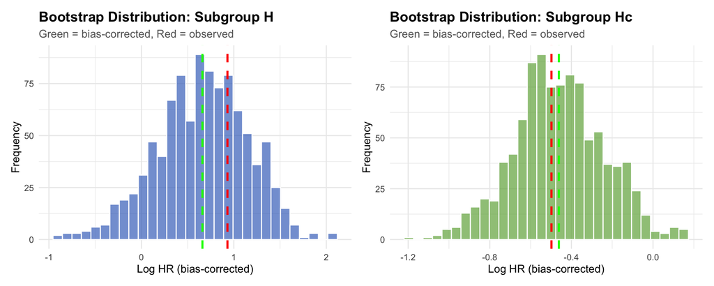

```r
if (!is.null(summaries$plots)) {
  summaries$plots$H_distribution + summaries$plots$Hc_distribution
}
```

# 7 DINA-Based Subgroup Identification

- **(A)** ForestSearch *using DINA for screening* – DINA’s per-covariate frontier contributes candidate cuts to the screening pool; the consistency search still performs selection.
- **(B)** *Standalone DINA* with parameters analogous to (A) – the same fit’s frontier (the candidates (A) screens) and its single selected subgroup via `dina_subgroup()`.
- **(C)** ForestSearch with `subgroup_method = "dina"` – subgroup *selection* is delegated to `dina_subgroup()`, then the standard ForestSearch bootstrap provides the selection bias-corrected Cox estimate.

```r
# Shared DINA *fit* settings (Cox / survival outcome => family mapped to "cox").
# Selection parameters (sg_focus, hr_threshold) live in the setup chunk under
# the fs_dina_* knobs so they can be tuned independently; (B) and (C) read them.
dina_seed   <- 8316951
dina_nfolds <- 2
# Harm/benefit floor on the natural-parameter (log-HR) scale for ratio measures
m_diff_dina <- log(fs_dina_hr_threshold)
```

## 7.1 (A) ForestSearch Using DINA for Screening

```r
t0 <- proc.time()

fs_dina_screen <- forestsearch(
  # --- Required data + roles ----------------------------------------------
  df.analysis,
  outcome.name              = outcome.name,
  event.name                = event.name,
  treat.name                = treat.name,
  id.name                   = id.name,
  confounders.name          = confounders.name,
  potentialOutcome.name     = NULL,           # default NULL
  flag_harm.name            = NULL,           # default NULL
  df.predict                = NULL,           # default NULL
  df.test                   = NULL,           # default NULL
  is.RCT                    = TRUE,           # default TRUE
  seedit                    = 8316951,        # default 8316951
  est.scale                 = "hr",           # default "hr"
  # --- Screening engines: GRF + LASSO + DINA ------------------------------
  use_lasso                 = TRUE,           # default TRUE
  use_grf                   = TRUE,           # default TRUE
  grf_res                   = NULL,           # default NULL
  grf_cuts                  = NULL,           # default NULL
  grf_depth                 = 2,              # default 2
  dmin.grf                  = 4,              # default 0.0
  frac.tau                  = 0.80,           # default 0.8
  vi.grf.min                = -0.2,           # default -0.2
  return_selected_cuts_only = TRUE,           # default TRUE
  tune_grf                  = FALSE,          # default FALSE
  use_dina                  = TRUE,           # default FALSE
  dina_res                  = NULL,           # default NULL
  dina_cuts                 = NULL,           # default NULL
  dina_args = list(                           # default list()
    seed = dina_seed, n_folds = dina_nfolds,
    scope = "wide", max_per_covariate = 3, max_subgroups = 10,
    selected_only = dina_screen_selected_only # set in setup chunk
  ),
  # --- Candidate-cut construction -----------------------------------------
  max_n_confounders         = 1000,           # default 1000
  conf_force                = NULL,           # default NULL
  defaultcut_names          = NULL,           # default NULL
  cut_type                  = "default",      # default "default"
  exclude_cuts              = NULL,           # default NULL
  replace_med_grf           = FALSE,          # default FALSE
  cont.cutoff               = 4,              # default 4
  conf.cont_medians         = NULL,           # default NULL
  conf.cont_medians_force   = NULL,           # default NULL
  conf.cont_jcuts           = NULL,           # default NULL
  # --- Selection engine ---------------------------------------------------
  subgroup_method           = "consistency",  # default "consistency"; or "dina"
  sg_focus                  = dina_screen_sg_focus,    # set in setup chunk
  selection_rule            = "neighborhood",  # default "neighborhood"
  effect_neighborhood       = 0.10,            # default 0.10
  # --- Subgroup constraints -----------------------------------------------
  n.min                     = 60,             # default 60
  d0.min                    = 10,             # default 10
  d1.min                    = 10,             # default 10
  maxk                      = 2,              # default 2
  max_subgroups_search      = dina_screen_max_subgroups_search,  # set in setup chunk
  # --- Thresholds (survival / HR scale) -----------------------------------
  hr.threshold              = dina_screen_hr_threshold,    # set in setup chunk
  hr.consistency            = dina_screen_hr_consistency,  # set in setup chunk
  effect.threshold          = NULL,           # default NULL (alias of hr.threshold)
  consistency.threshold     = NULL,           # default NULL (alias of hr.consistency)
  pconsistency.threshold    = 0.90,           # default 0.90
  m1.threshold              = Inf,            # default Inf
  minp                      = 0.025,          # default 0.025
  # --- Consistency search -------------------------------------------------
  fs.splits                 = 1000,           # default 1000
  stop_threshold            = 0.95,           # default 0.95
  use_twostage              = TRUE,           # default TRUE
  twostage_args             = list(),         # default list()
  max.minutes               = 3,              # default 3
  # --- Output / diagnostics -----------------------------------------------
  show_candidate_summary    = TRUE,           # default FALSE
  details                   = TRUE,           # default FALSE
  quiet                     = FALSE,          # default FALSE
  by.risk                   = 12,             # default 12
  plot.sg                   = FALSE,          # default FALSE
  plot.grf                  = FALSE,          # default FALSE
  # --- Parallel -----------------------------------------------------------
  parallel_args = list(
    plan = "multisession",
    workers = n_cores,
    show_message = TRUE
  )
)
```

```
#>
#> [forestsearch] Subgroup Identification Configuration
#>   Outcome type:   survival (Cox PH)
#>   Effect measure: HR (hazard ratio)
#>   Scale:          log (ratio)
#>
#>   Screening:      HR >= 0.90  (log: -0.1054)
#>   Consistency:    HR >= 0.80  (log: -0.2231)
#>   Consistency rate threshold: 90%
#>
#>   Interpretation:
#>     Candidates: subgroup hazard ratio >= 0.90
#>     Splits:     each split HR >= 0.80
```

```
#>   Search Alignment Diagnostic
```

```
#>
#>   Outcome:    time_months (survival)
```

```
#>   Treatment:  hormon
```

```
#>   Measure:    Hazard Ratio (HR)
```

```
#>
#>   ForestSearch searches for:
#>     Subgroups where hormon increases the event hazard
#>     (HR >= threshold in the candidate subgroup)
```

```
#>
#>   Thresholds:
#>     Screening: HR >= 0.900 in the candidate subgroup
#>     Consistency: HR >= 0.800 in each bootstrap split
```

```
#>
#>   Variable screening:
```

```
#>     LASSO: LASSO screening uses glmnet with family = "Cox (coxnet)".
#>     Variables with non-zero coefficients are retained.
```

```
#>     GRF:   causal_survival_forest() estimates treatment effect on
#>     survival probability. Positive CATE = treatment increases
#>     survival = treatment HELPS (events assumed adverse).
```

```
#>
#>   No alignment concerns detected.
```

```
#> GRF subgroup: er <= 0
#> GRF cuts identified: 1
#>   Cuts: er <= 0
#> DINA screening mode: selected cut (dina_subgroup, forestsearch criteria)
#> DINA cuts identified: 2
#>   Cuts: grade3 >= 1, pgr <= 32.5
#> Cox-LASSO selected: 4 of 7 candidate factors
#>   Omitted: age, meno, er
#> Candidate factors: 14
#>  [1] "er <= 0"     "pgr <= 32.5" "size <= 29"  "size <= 25"  "size <= 20"
#>  [6] "size <= 35"  "nodes <= 5"  "nodes <= 3"  "nodes <= 1"  "nodes <= 7"
#> [11] "pgr <= 110"  "pgr <= 7"    "pgr <= 132"  "grade3"
#> Number of possible configurations (<= maxk): maxk = 2 , # combinations = 406
#> Per-arm events criteria: control >= 10, treatment >= 10
#> Sample size criteria: n >= 60
#> Subgroup search completed in 0.01 minutes
#>
#> --- Filtering Summary ---
#>   Combinations evaluated: 406
#>   Passed variance check: 374
#>   Passed prevalence (>= 0.025 ): 374
#>   Passed redundancy check: 354
#>   Passed events counts (d0>= 10, d1>= 10): 270
#>   Passed sample size (n>= 60 ): 263
#>   Cox model fit successfully: 263
#>   Passed effect threshold (effect >= 0.9000): 43
#> -------------------------
#>
#> Found 43 subgroup candidate(s)
#> # of candidate subgroups (meeting all criteria) = 43
#> Removed 1 near-duplicate subgroups
#> # of unique initial candidates: 42
#> # Restricting to top stop_Kgroups = 30
#> # of candidates to evaluate: 30
#>
#> ==============================================================================================================
#> CANDIDATE EVALUATION PREVIEW (pre-consistency) (sg_focus = "hrMaxSG", selection_rule = "neighborhood")
#> ==============================================================================================================
#> Rank  HR      N      E     K    OF  IB  Subgroup
#> --------------------------------------------------------------------------------------------------------------
```

[output cut: 19 more lines]

```
#>   20   0.992    136    85    2  -   -   !{size <= 25} & !{nodes <= 5}
#>   21   0.922    132    72    2  -   -   {pgr <= 7} & {size <= 35}
#>   22   0.982    131    68    2  -   -   {grade3} & !{size <= 20}
#>   23   1.053    127    68    2  -   -   {grade3} & {pgr <= 32.5}
#>   24   0.937    127    81    2  -   -   {pgr <= 7} & !{nodes <= 1}
#>   25   0.955    125    84    2  -   -   !{size <= 20} & !{nodes <= 7}
#>   26   1.016    124    78    2  -   -   !{size <= 29} & !{nodes <= 5}
#>   27   0.911    120    65    2  -   -   {grade3} & !{nodes <= 1}
#>   28   1.175    105    60    2  -   -   !{size <= 35} & {pgr <= 110}
#>   29   1.081     97    57    2  -   -   {pgr <= 7} & !{size <= 25}
#>   30   1.075     93    63    2  -   -   !{size <= 25} & !{nodes <= 7}
#> --------------------------------------------------------------------------------------------------------------
#> To evaluate: 30   On frontier: 10   In band: 2
#> Legend: OF = on Pareto frontier;  IB = in effect-size band.
#> ==============================================================================================================
```

```
#> Parallel plan: multisession with 11 workers.
```

```
#> Parallel config: workers = 11 , batch_size = 22
#> Batch 1 / 2 : candidates 1 - 22
#> Batch 2 / 2 : candidates 23 - 30
#> Evaluated 30 of 30 candidates (complete)
#> 9 subgroups passed consistency threshold
#> SG focus = hrMaxSG
#>
#> ==============================================================================================================
#> CANDIDATE EVALUATION SUMMARY  (sg_focus = "hrMaxSG", selection_rule = "neighborhood")
#> ==============================================================================================================
#> Rank  HR      N      E     K    P      OF  IB  S  Subgroup
#> --------------------------------------------------------------------------------------------------------------
#>    1   2.335     61    31    2  1.000  -   *   *  {er <= 0} & {nodes <= 7}
#>    2   2.537     61    34    2  0.990  *   *   -  {er <= 0} & {size <= 35}
#>    3   1.105    242   130    2  0.940  *   -   -  !{size <= 25} & {pgr <= 132}
#>    4   1.105    233   123    2  0.950  *   -   -  !{size <= 25} & {pgr <= 110}
#>    5   1.146    216   120    2  0.970  *   -   -  !{size <= 29} & {pgr <= 132}
#>    6   1.148    207   113    2  0.940  *   -   -  !{size <= 29} & {pgr <= 110}
#>    7   1.169    149    91    2  0.910  *   -   -  !{size <= 29} & {pgr <= 32.5}
#>    8   1.951     82    45    1  1.000  *   -   -  {er <= 0}
#>    9   2.222     75    41    2  1.000  *   -   -  {er <= 0} & {pgr <= 32.5}
#> --------------------------------------------------------------------------------------------------------------
#> Evaluated: 30   Passed: 9   On frontier: 8   In band: 2   Selected: m=2
#> Legend: P = Pcons (consistency probability); OF = on Pareto frontier;  IB = in effect-size band; S = selected.
#> ==============================================================================================================
#>
#> Seconds and minutes forestsearch overall = 4.192 0.0699
#> Consistency algorithm used: twostage
#> Subgroup identified: {er <= 0} & {nodes <= 7}
```

```r
plan("sequential")
timings$fs_dina_screen <- (proc.time() - t0)["elapsed"]

cat("Identified subgroup (H):",
    paste(fs_dina_screen$sg.harm, collapse = " & "), "\n")
```

```
#> Identified subgroup (H): {er <= 0} & {nodes <= 7}
```

```r
cat("Subgroup size:", sum(fs_dina_screen$df.est$treat.recommend == 0),
    sprintf("(%.1f%% of ITT)\n",
            100 * mean(fs_dina_screen$df.est$treat.recommend == 0)))
```

```
#> Subgroup size: 61 (8.9% of ITT)
```

```r
dina_screen_cuts <- fs_dina_screen$dina_cuts
if (length(dina_screen_cuts) > 0) {
  gt(data.frame(
    `#` = seq_along(dina_screen_cuts),
    `DINA candidate cut` = dina_screen_cuts,
    check.names = FALSE
  )) |>
    tab_header(title = "DINA Screening Candidates Injected into ForestSearch") |>
    cols_align(align = "left")
} else {
  cat("DINA contributed no candidate cuts under the configured frontier.\n")
}
```

DINA Screening Candidates Injected into ForestSearch

| # | DINA candidate cut |
| --- | --- |
| 1 | grade3 >= 1 |
| 2 | pgr <= 32.5 |

```r
# Selection diagnostic for the DINA-screened run (selected subgroup marked).
pareto_frontier_table(fs_dina_screen)
```

Pareto frontier on (HR, N)

8 non-dominated candidate(s) | sg_focus = 'hrMaxSG' | HR shown on natural scale | diagnostic only

| S<sup>1,2</sup> | M.1 | M.2 | N | E | HR | P<sup>3</sup> | K |
| --- | --- | --- | --- | --- | --- | --- | --- |
|  | {er <= 0} | {size <= 35} | 61 | 34 | 2.54 | 0.99 | 2 |
|  | {er <= 0} | {pgr <= 32.5} | 75 | 41 | 2.22 | 1.00 | 2 |
|  | {er <= 0} |  | 82 | 45 | 1.95 | 1.00 | 1 |
|  | !{size <= 29} | {pgr <= 32.5} | 149 | 91 | 1.17 | 0.91 | 2 |
|  | !{size <= 29} | {pgr <= 110} | 207 | 113 | 1.15 | 0.94 | 2 |
|  | !{size <= 29} | {pgr <= 132} | 216 | 120 | 1.15 | 0.97 | 2 |
|  | !{size <= 25} | {pgr <= 110} | 233 | 123 | 1.11 | 0.95 | 2 |
|  | !{size <= 25} | {pgr <= 132} | 242 | 130 | 1.11 | 0.94 | 2 |

<sup>1</sup> S: selected subgroup (winner of the configured selection rule).  
<sup>2</sup> ★ marks the subgroup chosen by sg_focus = 'hrMaxSG'.  
<sup>3</sup> P: Pcons (consistency probability).

## 7.2 (B) Standalone DINA

```r
t0 <- proc.time()

dina_fit <- dina(
  df         = df.analysis,
  outcome    = outcome.name,
  treatment  = treat.name,
  covariates = confounders.name,
  family     = "cox",          # default "gaussian"; gaussian/binomial/poisson/cox
  status     = event.name,     # default NULL (required for family = "cox")
  # ... forwarded to dina_fit():
  seed              = dina_seed,   # default NULL
  n_folds           = dina_nfolds, # default 2L
  propensity_method = "logistic",  # default "logistic"
  baseline_method   = NULL,        # default NULL
  cross_fitting     = TRUE,        # default TRUE
  cens_type         = NULL,        # default NULL (no censoring model)
  cens_params       = list(),      # default list()
  n_grid            = 500L,        # default 500L
  eps               = 1e-6         # default 1e-6
)

timings$dina_standalone <- (proc.time() - t0)["elapsed"]
cat("Standalone DINA fit complete (family = cox).\n")
```

```
#> Standalone DINA fit complete (family = cox).
```

### 7.2.1 DINA Frontier (Screening Candidates)

```r
dina_fr <- dina_frontier(
  fit               = dina_fit,
  df                = df.analysis,
  covariates        = confounders.name,
  scope             = "wide",     # default "wide"; or "harm" (requires m_diff)
  m_diff            = NULL,        # default NULL (no effect floor under scope = "wide")
  n_min             = 60,         # default 60L
  direction         = "both",     # default "both"; or "left" / "right"
  max_per_covariate = 3,          # default 3L
  max_subgroups     = 10,         # default 10L
  digits            = 3           # default 3L
)

gt(dina_fr[, c("covariate", "direction", "threshold",
               "n_subgroup", "effect", "cut_expr")]) |>
  tab_header(
    title = "Standalone DINA Frontier",
    subtitle = "Per-covariate non-dominated (effect, N) candidates; effect on HR scale"
  ) |>
  fmt_number(columns = c(threshold, effect), decimals = 3) |>
  cols_label(
    covariate = "Covariate", direction = "Direction",
    threshold = "Threshold", n_subgroup = "N", effect = "HR",
    cut_expr = "Cut"
  ) |>
  cols_align(align = "left", columns = c(covariate, direction, cut_expr))
```

Standalone DINA Frontier

Per-covariate non-dominated (effect, N) candidates; effect on HR scale

| Covariate | Direction | Threshold | N | HR | Cut |
| --- | --- | --- | --- | --- | --- |
| nodes | right | 12.000 | 69 | 1.016 | nodes >= 12 |
| grade3 | right | 1.000 | 161 | 0.899 | grade3 >= 1 |
| er | left | 3.000 | 128 | 0.842 | er <= 3 |
| pgr | left | 2.000 | 129 | 0.840 | pgr <= 2 |
| size | right | 49.000 | 71 | 0.765 | size >= 49 |
| age | left | 39.000 | 65 | 0.701 | age <= 39 |
| meno | right | 1.000 | 396 | 0.569 | meno >= 1 |
| nodes | right | 11.000 | 84 | 0.945 | nodes >= 11 |
| pgr | left | 3.000 | 138 | 0.839 | pgr <= 3 |
| er | left | 5.000 | 154 | 0.838 | er <= 5 |

### 7.2.2 DINA-Selected Subgroup

```r
dina_sel <- dina_subgroup(
  fit                 = dina_fit,
  df                  = df.analysis,
  covariates          = confounders.name,
  m_diff              = m_diff_dina,
  n_min               = 60,             # default 60L
  direction           = "both",         # default "both"; or "left" / "right"
  sg_focus            = fs_dina_sg_focus,  # set in setup chunk
  selection_rule      = "neighborhood",  # default "neighborhood"; pareto/both (hrMaxSG/hrMinSG)
  effect_neighborhood = 0.10,            # default 0.10
  alpha               = 0.05             # default 0.05
)

if (isTRUE(dina_sel$found)) {
  op <- if (identical(dina_sel$direction, "left")) "<=" else ">="
  cat(sprintf("DINA-selected subgroup: %s %s %s\n",
              dina_sel$covariate, op, format(dina_sel$threshold)))
  cat(sprintf("Direction: %s | N = %d\n",
              dina_sel$direction, dina_sel$n_subgroup))
} else {
  cat("Standalone DINA selected no subgroup meeting the criteria.\n")
}
```

[output not shown]

## 7.3 (C) ForestSearch with `subgroup_method = "dina"`

In this mode ForestSearch delegates subgroup *selection* to `dina_subgroup()`, bypassing GRF, LASSO and the consistency search. The selection criteria are inherited from this call’s `sg_focus`, `n.min` and `hr.threshold` (mapped to the log-HR harm floor); `dina_args` supplies only the fit tuning. The returned object is a standard `forestsearch` result, so the existing bootstrap machinery applies unchanged.

```r
t0 <- proc.time()

fs_dina <- forestsearch(
  # --- Required data + roles ----------------------------------------------
  df.analysis,
  outcome.name        = outcome.name,
  event.name          = event.name,
  treat.name          = treat.name,
  id.name             = id.name,
  confounders.name    = confounders.name,
  df.predict          = NULL,            # default NULL
  df.test             = NULL,            # default NULL
  is.RCT              = TRUE,            # default TRUE
  seedit              = 8316951,         # default 8316951
  # --- DINA-selection mode ------------------------------------------------
  subgroup_method     = "dina",          # default "consistency"
  dina_args           = list(seed = dina_seed, n_folds = dina_nfolds),  # fit tuning only
  dina_select_statistic = fs_dina_select_statistic,  # setup-chunk selector (top-level)
  dina_res            = NULL,            # default NULL (reuse a fitted dina object)
  # --- Selection criteria (passed through to dina_subgroup) ---------------
  sg_focus            = fs_dina_sg_focus,  # set in setup chunk
  selection_rule      = "neighborhood",  # default "neighborhood"
  effect_neighborhood = 0.10,            # default 0.10
  n.min               = 60,              # default 60
  hr.threshold        = fs_dina_hr_threshold,  # set in setup chunk (-> log-HR floor)
  # --- Tier-2 de-biased gate ----------------------------------------------
  debias_gate         = run_debias_gate,           # set in setup chunk
  debias_gate_args    = list(draws = gate_draws,
                             family_native_neighborhood = fs_dina_family_native_nbhd),
  # --- Output -------------------------------------------------------------
  details             = TRUE             # default FALSE
  # NOTE: subgroup_method = "dina" bypasses GRF, LASSO and the consistency
  # search; use_grf / use_lasso / use_twostage / fs.splits / maxk /
  # stop_threshold and related parameters do not apply in this mode.
)
```

```
#>
#> [forestsearch] DINA selection (subgroup_method = "dina")
#>   Family:              cox
#>   sg_focus:            hrMaxSG
#>   selection_rule:      neighborhood
#>   effect_neighborhood: 0.1
#>   Harm floor:          m_diff = -0.1054  (hr.threshold = 0.9)
#>   n.min:               60
#>   DINA frontier candidates (per-covariate non-dominated):
#>      covariate direction threshold n_subgroup    effect    cut_expr
#>          nodes     right        12         69 1.0159889 nodes >= 12
#>         grade3     right         1        161 0.8987391 grade3 >= 1
#>             er      left         3        128 0.8419853     er <= 3
#>            pgr      left         2        129 0.8396503    pgr <= 2
#>           size     right        49         71 0.7648082  size >= 49
#>            age      left        39         65 0.7009914   age <= 39
#>           meno     right         1        396 0.5686406   meno >= 1
#>          nodes     right        11         84 0.9451563 nodes >= 11
#>            pgr      left         3        138 0.8394508    pgr <= 3
#>             er      left         5        154 0.8375058     er <= 5
```

```
#>   Candidates searched:  4920
#>   Candidates qualifying (>= floor, >= n.min): 84
#>   SELECTED: {grade3 >=  1} & {pgr <= 10}  (n = 89, mean tau-hat = 0.0563)
```

```
#> DINA-selected subgroup: {grade3 >= 1} & {pgr <= 10}
```

```r
timings$fs_dina_select <- (proc.time() - t0)["elapsed"]

cat("DINA-selected subgroup (H):",
    paste(fs_dina$sg.harm, collapse = " & "), "\n")
```

```
#> DINA-selected subgroup (H): {grade3 >= 1} & {pgr <= 10}
```

```r
cat("Subgroup size:", sum(fs_dina$df.est$treat.recommend == 0),
    sprintf("(%.1f%% of ITT)\n",
            100 * mean(fs_dina$df.est$treat.recommend == 0)))
```

```
#> Subgroup size: 89 (13.0% of ITT)
```

### 7.3.1 Bootstrap Bias-Corrected Cox Estimates

The within-subgroup Cox hazard ratio is upwardly biased by selection. The ForestSearch bootstrap corrects this by re-running the full pipeline on each resample; because the result above was produced in DINA-selection mode, each replicate re-fits DINA and re-runs `dina_subgroup()` from scratch – so the correction reflects the DINA selection process itself.

```r
# Runs only when DINA identified a subgroup.  The bootstrap bias-corrects an
# identified subgroup's effect, so there is nothing to do otherwise.
t0 <- proc.time()

# Diagnostic run: sequential plan + details = TRUE so per-iteration output is
# visible and errors surface in order (helpful while validating DINA-mode
# bootstrap). Switch plan back to "multisession" for production speed.

fs_dina_bc <- forestsearch_bootstrap_dofuture(
  fs.est = fs_dina,
  nb_boots = NB,
  show_three = FALSE,
  details = TRUE,
  parallel_args = list(
    plan = "multisession",
    workers = n_cores,
    show_message = TRUE
  )
)
```

```
#> Bootstrap parallel config: Using user-provided settings
```

```
#> System max cores available: 14
```

```
#> Bootstrap will use: 11 workers with 'multisession' plan
```

```
#> Parallel plan: multisession with 11 workers.
```

```
#> Ystar matrix generated should be 'boots x N': 1000 x 686
#>
#> ForestSearch parameters for bootstrap iterations:
#>   - subgroup_method: dina
#>   - sg_focus: hrMaxSG
#>   - hr.threshold: 0.9
#>   - n.min: 60
#>   - selection_rule: neighborhood
#>   - effect_neighborhood: 0.1
#>   Bootstrap-specific overrides:
#>   - dina_res / dina_cuts: NULL (forces DINA re-fit + re-selection)
#>   - GRF / LASSO / consistency search: bypassed in DINA mode
#>   - parallel_args: sequential (prevents nested parallelism)
#>   - details: per-iteration (show_three -> first 3 only)
#>   - plot.sg: FALSE
#>   - plot.grf: FALSE
```

```
#> Bootstrap iteration 1/1000
```

```
#> Bootstrap iteration 10/1000
```

```
#>   Bootstrap 36: Low events in NEW subgroup H* (Control=19, Treat=4)
```

```
#> Bootstrap iteration 50/1000
```

```
#> Bootstrap iteration 100/1000
```

```
#>   Bootstrap 197: Low events in NEW subgroup H* (Control=19, Treat=4)
```

```
#> Bootstrap iteration 250/1000
```

```
#>   Bootstrap 384: Low events in NEW subgroup H* (Control=13, Treat=2)
```

```
#>   Bootstrap 400: Low events in NEW subgroup H* (Control=14, Treat=3)
```

```
#> Bootstrap iteration 500/1000
```

```
#> Bootstrap iteration 750/1000
```

```
#>   Bootstrap 800: Low events in NEW subgroup H* (Control=19, Treat=4)
```

```
#>   Bootstrap 853: Low events in NEW subgroup H* (Control=17, Treat=3)
```

```
#>   Bootstrap 904: Low events in NEW subgroup H* (Control=19, Treat=4)
```

```
#>   Bootstrap 995: Low events in NEW subgroup H* (Control=19, Treat=4)
```

```
#> Bootstrap iteration 1000/1000
```

```
#>
#> === Bootstrap Analysis Complete ===
#> Success rate: 95.8% (958/1000)
#>
#> H (Questionable) Estimates:
#>   Unadjusted:       1.5994 (0.8796,2.9081)
#>   Bias-corrected:  0.9155 (0.3659,2.2903)
#>
#> Hc (Recommend) Estimates:
#>   Unadjusted:       0.6291 (0.4823,0.8205)
#>   Bias-corrected:  0.666 (0.3961,1.1199)
#> ===================================
```

```r
plan("sequential")
timings$fs_dina_bootstrap <- (proc.time() - t0)["elapsed"]

cat("\nDINA-mode bootstrap completed in",
    round(timings$fs_dina_bootstrap / 60, 1), "minutes\n")
```

```
#>
#> DINA-mode bootstrap completed in 1.4 minutes
```

```r
# Shown only when DINA selected no subgroup at the configured harm floor.
timings$fs_dina_bootstrap <- 0
cat("DINA (subgroup_method = \"dina\") identified no subgroup at",
    "hr.threshold =", fs_dina_hr_threshold, "-- bootstrap skipped.\n",
    "DINA's model-based effect is attenuated relative to the raw Cox HR,",
    "so this floor may not be reached; see the standalone DINA frontier (B)",
    "for the achievable effect range, and lower the DINA harm floor if a",
    "bootstrap demonstration is desired.\n")
```

```r
dina_summaries <- summarize_bootstrap_results(
  sgharm = fs_dina$sg.harm,
  boot_results = fs_dina_bc,
  create_plots = FALSE,
  est.scale = "hr"
)
```

```
#>
#> ===============================================================
#>            BOOTSTRAP ANALYSIS SUMMARY
#> ===============================================================
#>
#> IDENTIFIED SUBGROUP:
#> -------------------------------------------------------------
#>   H: {grade3 >= 1} & {pgr <= 10}
#>
#> BOOTSTRAP SUCCESS METRICS:
#> -------------------------------------------------------------
#>   Total iterations:              1000
#>   Successful subgroup ID:        958 (95.8%)
#>   Failed to find subgroup:       42 (4.2%)
#>
#> TIMING ANALYSIS:
#> -------------------------------------------------------------
#> Overall:
#>   Total bootstrap time:          1.38 minutes (0.02 hours)
#>   Average per iteration:         0.00 min (0.1 sec)
```

```r
dina_summaries$table
```

**Treatment Effect by Subgroup**

Bootstrap bias-corrected estimates (1000 iterations)

| Subgroup | Sample Size N | Sample Size N<sub>T</sub> | Sample Size Events | Survival Med<sub>T</sub> | Survival Med<sub>C</sub> | Survival RMST<sub>d</sub> | Treatment Effect HR (95% CI)†<sup>1</sup> | Treatment Effect HR‡ (95% CI)<sup>2</sup> |
| --- | --- | --- | --- | --- | --- | --- | --- | --- |
| Qstnbl<sup>3</sup> | 89 (13.0%) | 26 (29.2%) | 50 (56.2%) | 18 | 36.4 | -8 | 1.60 (0.88, 2.91) | 0.92 (0.37,2.29) |
| Recmnd | 597 (87.0%) | 220 (36.9%) | 249 (41.7%) | 77.9 | 55.3 | 9.5 | 0.63 (0.48, 0.82) | 0.67 (0.40,1.12) |

<sup>1</sup> **Unadjusted HR**: Standard Cox regression hazard ratio with robust standard errors  
<sup>2</sup> **Bias-corrected HR**: Bootstrap-adjusted estimate using infinitesimal jackknife method (1000 iterations). Corrects for optimism in subgroup selection.  
<sup>3</sup> **Identified subgroup**: {grade3 >= 1} & {pgr <= 10}  
*Note*: Med = Median survival time (months). RMST<sub>d</sub> = Restricted mean survival time difference. Subgroup identified in 95.8% of bootstrap samples.

#### 7.3.1.1 Tier-2 de-biased gate (counterpart to the Tier-1 bootstrap)

The same Tier-2-vs-Tier-1 comparison as the main analysis, for the DINA-selection fit. The gate de-biases against DINA’s **own** qualifying candidate family (re-running nothing), while the bootstrap above re-runs DINA on every resample.

For DINA the two tiers are **not** expected to agree as tightly as for the consistency method. DINA selects on its survival-forest **tau-hat**, but the gate can only re-select on the perturbed **Cox** effect; over a large depth-2 candidate family the gate’s winner’s-curse term can therefore exceed the bootstrap’s and over-correct the selected subgroup. To keep the gate’s re-selection neighbourhood close to DINA’s own selection band, the gate by default restricts that family to candidates competitive on DINA’s native tau-hat, matching the band to `effect_neighborhood` (the recommended default, used here via `fs_dina_family_native_nbhd <- NULL`; set an explicit number for a different band, or `>= 1` to de-bias against the full unrestricted family). The complement is the induced residual rather than a max-over-family selection, so it agrees across tiers regardless. This band tunes only the *candidate-competition* part of the bias – the gate holds the survival forest fixed, so the forest-refit optimism is invisible to it; treat the full bootstrap as the reference for DINA and the gate as a fast, conservative check.

DINA-selected subgroup: {grade3 >= 1} & {pgr <= 10} (complement = remaining subjects)

| quantity | Tier 2 (gate) | Tier 1 (bootstrap) |
| --- | --- | --- |
| naive HR (95% CI) | 1.599 (0.880, 2.908) | 1.599 (0.880, 2.908) |
| de-biased HR (95% CI) | 1.225 (0.891, 1.683) | 0.915 (0.366, 2.290) |
| complement naive HR (95% CI) | 0.629 (0.482, 0.821) | 0.629 (0.482, 0.821) |
| complement de-biased HR (95% CI) | 0.633 (0.380, 1.052) | 0.666 (0.396, 1.120) |

Timing: Tier 1 bootstrap (1000 boots) 83.4 s (1.4 min); Tier 2 gate 0.07 s -> **1158x** faster (the bootstrap scales with `NB`, the gate does not).

Gate harm flag = **TRUE** (de-biased HR 1.225 vs gate 1.00); selection bias 0.2632 (log-HR); candidate family = 1. Re-selection rule = `effMaxSG` (a Cox-effect proxy for DINA’s tau-hat); native-family band = default (matched to effect_neighborhood). De-biased CI: infinitesimal jackknife (Tier-1 analogue) (IJ SE 0.162 vs robust SE 0.305, log-HR).

The Tier-1 bias-corrected table above, rebuilt from the Tier-2 gate object (the descriptive columns and naive effect are tier-independent; the bias-corrected column carries the gate’s de-biased estimate for the subgroup and its complement).

```r
gate_estimates_table(fs_dina, boot_results = fs_dina_bc, est.scale = "hr", digits = 2)
```

**Treatment Effect by Subgroup**

Tier-2 de-biased estimate (multiplier bootstrap, 5000 draws)

| Subgroup | Sample Size N | Sample Size N<sub>T</sub> | Sample Size Events | Survival Med<sub>T</sub> | Survival Med<sub>C</sub> | Survival RMST<sub>d</sub> | Treatment Effect HR (95% CI)†<sup>1</sup> | Treatment Effect HR‡ (95% CI)<sup>2</sup> |
| --- | --- | --- | --- | --- | --- | --- | --- | --- |
| Qstnbl<sup>3</sup> | 89 (13.0%) | 26 (29.2%) | 50 (56.2%) | 18 | 36.4 | -8 | 1.60 (0.88, 2.91) | 1.22 (0.89,1.68) |
| Recmnd | 597 (87.0%) | 220 (36.9%) | 249 (41.7%) | 77.9 | 55.3 | 9.5 | 0.63 (0.48, 0.82) | 0.63 (0.38,1.05) |

<sup>1</sup> **Unadjusted HR**: Standard Cox regression hazard ratio with robust standard errors  
<sup>2</sup> **Bias-corrected HR**: Bootstrap-adjusted estimate using infinitesimal jackknife method (5000 iterations). Corrects for optimism in subgroup selection.  
<sup>3</sup> **Identified subgroup**: {grade3 >= 1} & {pgr <= 10}  
*Note*: Med = Median survival time (months). RMST<sub>d</sub> = Restricted mean survival time difference.

## 7.4 (D) ForestSearch with `subgroup_method = "grf"`

In this mode ForestSearch delegates subgroup *selection* to GRF – a causal-forest policy tree (`grf_selection = "tree"`) or the doubly-robust-score frontier (`"frontier"`) – bypassing LASSO, DINA and the consistency search. The selection criteria are inherited from this call’s `sg_focus` (mapped to the GRF frontier/tree rule), `n.min`, `grf_depth`, `grf_selection` and the DR-score harm floor `dmin.grf`. The returned object is a standard `forestsearch` result, so the existing bootstrap machinery applies unchanged.

```r
t0 <- proc.time()

fs_grf <- forestsearch(
  # --- Required data + roles ----------------------------------------------
  df.analysis,
  outcome.name        = outcome.name,
  event.name          = event.name,
  treat.name          = treat.name,
  id.name             = id.name,
  confounders.name    = confounders.name,
  df.predict          = NULL,            # default NULL
  df.test             = NULL,            # default NULL
  is.RCT              = TRUE,            # default TRUE
  seedit              = 8316951,         # default 8316951 (also seeds the forest)
  # --- GRF-selection mode -------------------------------------------------
  subgroup_method     = "grf",           # default "consistency"
  grf_selection       = fs_grf_demo_selection,  # set in setup chunk ("tree" | "frontier")
  grf_select_statistic = fs_grf_select_statistic,  # set in setup chunk (frontier only)
  grf_depth           = fs_grf_demo_depth,      # set in setup chunk (tree / DR-pair depth)
  dmin.grf            = fs_grf_demo_dmin,        # set in setup chunk (DR-score harm floor)
  frac.tau            = 0.8,             # default 0.8 (RMST truncation fraction)
  grf_res             = NULL,            # default NULL (reuse a fitted forest)
  # --- Selection criteria -------------------------------------------------
  sg_focus            = fs_grf_sg_focus,  # set in setup chunk (-> GRF frontier/tree rule)
  selection_rule      = "neighborhood",  # default "neighborhood"
  effect_neighborhood = 0.10,            # default 0.10
  n.min               = 60,              # default 60
  # --- Tier-2 de-biased gate ----------------------------------------------
  debias_gate         = run_debias_gate,           # set in setup chunk
  debias_gate_args    = list(draws = gate_draws,
                             family_native_neighborhood = fs_grf_family_native_nbhd),
  # --- Output -------------------------------------------------------------
  details             = TRUE             # default FALSE
  # NOTE: subgroup_method = "grf" bypasses LASSO, DINA and the consistency
  # search; use_lasso / use_dina / use_twostage / fs.splits / maxk /
  # hr.threshold / pconsistency.threshold do not apply in this mode.
)
```

```
#>
#> [forestsearch] Subgroup Identification Configuration
#>   Outcome type:   survival (Cox PH)
#>   Effect measure: HR (hazard ratio)
#>   Scale:          log (ratio)
#>
#>   Screening:      HR >= 1.25  (log: 0.2231)
#>   Consistency:    HR >= 1.00  (log: 0.0000)
#>   Consistency rate threshold: 90%
#>
#>   Interpretation:
#>     Candidates: subgroup hazard ratio >= 1.25
#>     Splits:     each split HR >= 1.00
```

```
#>   Search Alignment Diagnostic
```

```
#>
#>   Outcome:    time_months (survival)
```

```
#>   Treatment:  hormon
```

```
#>   Measure:    Hazard Ratio (HR)
```

```
#>
#>   ForestSearch searches for:
#>     Subgroups where hormon increases the event hazard
#>     (HR >= threshold in the candidate subgroup)
```

```
#>
#>   Thresholds:
#>     Screening: HR >= 1.250 in the candidate subgroup
#>     Consistency: HR >= 1.000 in each bootstrap split
```

```
#>
#>   Variable screening:
```

```
#>     LASSO: LASSO screening uses glmnet with family = "Cox (coxnet)".
#>     Variables with non-zero coefficients are retained.
```

```
#>     GRF:   causal_survival_forest() estimates treatment effect on
#>     survival probability. Positive CATE = treatment increases
#>     survival = treatment HELPS (events assumed adverse).
```

```
#>
#>   No alignment concerns detected.
```

```
#>
#> [forestsearch] GRF selection (subgroup_method = "grf")
#>   Outcome type:   survival
#>   grf_depth:      2
#>   dmin.grf:       0
#>   frac.tau:       0.8
#>   n.min:          60
#>   SELECTED (depth 1): er <= 0
```

```
#> GRF-selected subgroup: {er <= 0}
```

```r
timings$fs_grf_select <- (proc.time() - t0)["elapsed"]

cat("GRF-selected subgroup (H):",
    paste(fs_grf$sg.harm, collapse = " & "), "\n")
```

```
#> GRF-selected subgroup (H): {er <= 0}
```

```r
cat("Subgroup size:", sum(fs_grf$df.est$treat.recommend == 0),
    sprintf("(%.1f%% of ITT)\n",
            100 * mean(fs_grf$df.est$treat.recommend == 0)))
```

```
#> Subgroup size: 82 (12.0% of ITT)
```

### 7.4.1 Bootstrap Bias-Corrected Cox Estimates

The within-subgroup Cox hazard ratio is upwardly biased by selection. The ForestSearch bootstrap corrects this by re-running the full pipeline on each resample; because the result above was produced in GRF-selection mode, each replicate re-fits the causal forest and re-runs GRF selection from scratch – so the correction reflects the GRF selection process itself.

```r
# Runs only when GRF identified a subgroup.  The bootstrap bias-corrects an
# identified subgroup's effect, so there is nothing to do otherwise.
t0 <- proc.time()

fs_grf_bc <- forestsearch_bootstrap_dofuture(
  fs.est = fs_grf,
  nb_boots = NB,
  show_three = FALSE,
  details = TRUE,
  parallel_args = list(
    plan = "multisession",
    workers = n_cores,
    show_message = TRUE
  )
)
```

```
#> Bootstrap parallel config: Using user-provided settings
```

```
#> System max cores available: 14
```

```
#> Bootstrap will use: 11 workers with 'multisession' plan
```

```
#> Parallel plan: multisession with 11 workers.
```

```
#> Ystar matrix generated should be 'boots x N': 1000 x 686
#>
#> ForestSearch parameters for bootstrap iterations:
#>   - subgroup_method: grf
#>   - sg_focus: hrMaxSG
#>   - maxk: 2
#>   - fs.splits: 1000
#>   - max_subgroups_search: 30
#>   - hr.threshold: 1.25
#>   - hr.consistency: 1
#>   - pconsistency.threshold: 0.9
#>   - n.min: 60
#>   - use_twostage: TRUE
#>   - use_lasso: TRUE
#>   - use_grf: TRUE
#>   Bootstrap-specific overrides:
#>   - grf_res: NULL (forces re-selection)
#>   - grf_cuts: NULL (forces re-selection)
#>   - parallel_args: sequential (prevents nested parallelism)
#>   - details: per-iteration (show_three -> first 3 only)
#>   - plot.sg: FALSE
#>   - plot.grf: FALSE
```

```
#> Bootstrap iteration 1/1000
```

```
#>   Bootstrap 6: Low events in NEW subgroup H* (Control=19, Treat=4)
```

```
#>   Bootstrap 7: Low events in NEW subgroup H* (Control=19, Treat=4)
```

```
#> Bootstrap iteration 10/1000
```

```
#>   Bootstrap 10: Low events in NEW subgroup H* (Control=19, Treat=4)
```

```
#>   Bootstrap 36: Low events in NEW subgroup H* (Control=19, Treat=4)
```

```
#> Bootstrap iteration 50/1000
```

```
#>   Bootstrap 51: Low events in NEW subgroup H* (Control=19, Treat=4)
```

```
#>   Bootstrap 60: Low events in NEW subgroup H* (Control=14, Treat=3)
```

```
#>   Bootstrap 63: Low events in NEW subgroup H* (Control=19, Treat=4)
```

```
#>   Bootstrap 69: Low events in NEW subgroup H* (Control=19, Treat=4)
```

```
#>   Bootstrap 75: Low events in NEW subgroup H* (Control=19, Treat=4)
```

```
#>   Bootstrap 78: Low events in NEW subgroup H* (Control=22, Treat=2)
```

```
#>   Bootstrap 97: Low events in NEW subgroup H* (Control=17, Treat=3)
```

```
#>   Bootstrap 98: Low events in NEW subgroup H* (Control=7, Treat=4)
```

```
#>   Bootstrap 99: Low events in NEW subgroup H* (Control=19, Treat=4)
```

```
#> Bootstrap iteration 100/1000
```

```
#>   Bootstrap 109: Low events in NEW subgroup H* (Control=19, Treat=4)
```

```
#>   Bootstrap 118: Low events in NEW subgroup H* (Control=19, Treat=4)
```

```
#>   Bootstrap 120: Low events in NEW subgroup H* (Control=19, Treat=4)
```

```
#>   Bootstrap 130: Low events in NEW subgroup H* (Control=19, Treat=4)
```

```
#>   Bootstrap 148: Low events in NEW subgroup H* (Control=19, Treat=4)
```

```
#>   Bootstrap 161: Low events in NEW subgroup H* (Control=19, Treat=4)
```

```
#>   Bootstrap 195: Low events in NEW subgroup H* (Control=19, Treat=4)
```

```
#>   Bootstrap 197: Low events in NEW subgroup H* (Control=19, Treat=4)
```

```
#>   Bootstrap 207: Low events in NEW subgroup H* (Control=17, Treat=3)
```

```
#>   Bootstrap 215: Low events in NEW subgroup H* (Control=19, Treat=4)
```

```
#> Bootstrap iteration 250/1000
```

```
#>   Bootstrap 298: Low events in NEW subgroup H* (Control=19, Treat=4)
```

```
#>   Bootstrap 301: Low events in NEW subgroup H* (Control=21, Treat=4)
```

```
#>   Bootstrap 321: Low events in NEW subgroup H* (Control=14, Treat=2)
```

```
#>   Bootstrap 328: Low events in NEW subgroup H* (Control=19, Treat=4)
```

```
#>   Bootstrap 338: Low events in NEW subgroup H* (Control=19, Treat=4)
```

```
#>   Bootstrap 344: Low events in NEW subgroup H* (Control=19, Treat=4)
```

```
#>   Bootstrap 351: Low events in NEW subgroup H* (Control=19, Treat=4)
```

```
#>   Bootstrap 353: Low events in NEW subgroup H* (Control=19, Treat=4)
```

```
#>   Bootstrap 384: Low events in NEW subgroup H* (Control=19, Treat=4)
```

```
#>   Bootstrap 392: Low events in NEW subgroup H* (Control=19, Treat=4)
```

```
#>   Bootstrap 400: Low events in NEW subgroup H* (Control=19, Treat=4)
```

```
#>   Bootstrap 419: Low events in NEW subgroup H* (Control=17, Treat=3)
```

```
#>   Bootstrap 455: Low events in NEW subgroup H* (Control=17, Treat=3)
```

```
#>   Bootstrap 466: Low events in NEW subgroup H* (Control=19, Treat=4)
```

```
#>   Bootstrap 470: Low events in NEW subgroup H* (Control=7, Treat=4)
```

```
#>   Bootstrap 476: Low events in NEW subgroup H* (Control=19, Treat=4)
```

```
#>   Bootstrap 490: Low events in NEW subgroup H* (Control=7, Treat=4)
```

```
#>   Bootstrap 495: Low events in NEW subgroup H* (Control=19, Treat=4)
```

```
#> Bootstrap iteration 500/1000
```

```
#>   Bootstrap 524: Low events in NEW subgroup H* (Control=14, Treat=3)
```

```
#>   Bootstrap 547: Low events in NEW subgroup H* (Control=19, Treat=4)
```

```
#>   Bootstrap 550: Low events in NEW subgroup H* (Control=19, Treat=4)
```

```
#>   Bootstrap 557: Low events in NEW subgroup H* (Control=7, Treat=4)
```

```
#>   Bootstrap 565: Low events in NEW subgroup H* (Control=17, Treat=3)
```

```
#>   Bootstrap 566: Low events in NEW subgroup H* (Control=19, Treat=4)
```

```
#>   Bootstrap 567: Low events in NEW subgroup H* (Control=19, Treat=4)
```

```
#>   Bootstrap 571: Low events in NEW subgroup H* (Control=19, Treat=4)
```

```
#>   Bootstrap 605: Low events in NEW subgroup H* (Control=19, Treat=4)
```

```
#>   Bootstrap 627: Low events in NEW subgroup H* (Control=19, Treat=4)
```

```
#>   Bootstrap 632: Low events in NEW subgroup H* (Control=19, Treat=4)
```

```
#>   Bootstrap 656: Low events in NEW subgroup H* (Control=14, Treat=3)
```

```
#>   Bootstrap 657: Low events in NEW subgroup H* (Control=22, Treat=4)
```

```
#>   Bootstrap 681: Low events in NEW subgroup H* (Control=19, Treat=4)
```

```
#>   Bootstrap 733: Low events in NEW subgroup H* (Control=19, Treat=4)
```

```
#>   Bootstrap 747: Low events in NEW subgroup H* (Control=19, Treat=4)
```

```
#> Bootstrap iteration 750/1000
```

```
#>   Bootstrap 772: Low events in NEW subgroup H* (Control=17, Treat=3)
```

```
#>   Bootstrap 795: Low events in NEW subgroup H* (Control=19, Treat=4)
```

```
#>   Bootstrap 800: Low events in NEW subgroup H* (Control=17, Treat=3)
```

```
#>   Bootstrap 801: Low events in NEW subgroup H* (Control=22, Treat=2)
```

```
#>   Bootstrap 808: Low events in NEW subgroup H* (Control=19, Treat=4)
```

```
#>   Bootstrap 825: Low events in NEW subgroup H* (Control=19, Treat=4)
```

```
#>   Bootstrap 829: Low events in NEW subgroup H* (Control=19, Treat=4)
```

```
#>   Bootstrap 843: Low events in NEW subgroup H* (Control=19, Treat=4)
```

```
#>   Bootstrap 853: Low events in NEW subgroup H* (Control=19, Treat=4)
```

```
#>   Bootstrap 870: Low events in NEW subgroup H* (Control=19, Treat=4)
```

```
#>   Bootstrap 872: Low events in NEW subgroup H* (Control=19, Treat=4)
```

```
#>   Bootstrap 903: Low events in NEW subgroup H* (Control=19, Treat=4)
```

```
#>   Bootstrap 904: Low events in NEW subgroup H* (Control=19, Treat=4)
```

```
#>   Bootstrap 947: Low events in NEW subgroup H* (Control=19, Treat=4)
```

```
#>   Bootstrap 964: Low events in NEW subgroup H* (Control=19, Treat=4)
```

```
#>   Bootstrap 967: Low events in NEW subgroup H* (Control=19, Treat=4)
```

```
#>   Bootstrap 984: Low events in NEW subgroup H* (Control=19, Treat=4)
```

```
#>   Bootstrap 988: Low events in NEW subgroup H* (Control=8, Treat=4)
```

```
#>   Bootstrap 995: Low events in NEW subgroup H* (Control=19, Treat=4)
```

```
#> Bootstrap iteration 1000/1000
```

```
#>
#> === Bootstrap Analysis Complete ===
#> Success rate: 100.0% (1000/1000)
#>
#> H (Questionable) Estimates:
#>   Unadjusted:       1.9514 (1.0366,3.6735)
#>   Bias-corrected:  1.044 (0.483,2.2566)
#>
#> Hc (Recommend) Estimates:
#>   Unadjusted:       0.615 (0.4723,0.8008)
#>   Bias-corrected:  0.6622 (0.388,1.13)
#> ===================================
```

```r
plan("sequential")
timings$fs_grf_bootstrap <- (proc.time() - t0)["elapsed"]

cat("\nGRF-mode bootstrap completed in",
    round(timings$fs_grf_bootstrap / 60, 1), "minutes\n")
```

```
#>
#> GRF-mode bootstrap completed in 4.1 minutes
```

```r
# Shown only when GRF selected no subgroup at the configured DR-score floor.
timings$fs_grf_bootstrap <- 0
cat("GRF (subgroup_method = \"grf\") identified no subgroup at",
    "dmin.grf =", fs_grf_demo_dmin, "-- bootstrap skipped.\n",
    "Lower the DR-score floor (dmin.grf) or switch grf_selection /",
    "grf_depth if a bootstrap demonstration is desired.\n")
```

```r
grf_summaries <- summarize_bootstrap_results(
  sgharm = fs_grf$sg.harm,
  boot_results = fs_grf_bc,
  create_plots = FALSE,
  est.scale = "hr"
)
```

```
#>
#> ===============================================================
#>            BOOTSTRAP ANALYSIS SUMMARY
#> ===============================================================
#>
#> IDENTIFIED SUBGROUP:
#> -------------------------------------------------------------
#>   H: {er <= 0}
#>
#> BOOTSTRAP SUCCESS METRICS:
#> -------------------------------------------------------------
#>   Total iterations:              1000
#>   Successful subgroup ID:        1000 (100.0%)
#>   Failed to find subgroup:       0 (0.0%)
#>
#> TIMING ANALYSIS:
#> -------------------------------------------------------------
#> Overall:
#>   Total bootstrap time:          4.06 minutes (0.07 hours)
#>   Average per iteration:         0.00 min (0.2 sec)
```

```r
grf_summaries$table
```

**Treatment Effect by Subgroup**

Bootstrap bias-corrected estimates (1000 iterations)

| Subgroup | Sample Size N | Sample Size N<sub>T</sub> | Sample Size Events | Survival Med<sub>T</sub> | Survival Med<sub>C</sub> | Survival RMST<sub>d</sub> | Treatment Effect HR (95% CI)†<sup>1</sup> | Treatment Effect HR‡ (95% CI)<sup>2</sup> |
| --- | --- | --- | --- | --- | --- | --- | --- | --- |
| Qstnbl<sup>3</sup> | 82 (12.0%) | 26 (31.7%) | 45 (54.9%) | 22.9 | 43.7 | -14 | 1.95 (1.04, 3.67) | 1.04 (0.48,2.26) |
| Recmnd | 604 (88.0%) | 220 (36.4%) | 254 (42.1%) | 66.7 | 52.6 | 9.3 | 0.61 (0.47, 0.80) | 0.66 (0.39,1.13) |

<sup>1</sup> **Unadjusted HR**: Standard Cox regression hazard ratio with robust standard errors  
<sup>2</sup> **Bias-corrected HR**: Bootstrap-adjusted estimate using infinitesimal jackknife method (1000 iterations). Corrects for optimism in subgroup selection.  
<sup>3</sup> **Identified subgroup**: {er <= 0}  
*Note*: Med = Median survival time (months). RMST<sub>d</sub> = Restricted mean survival time difference. Subgroup identified in 100.0% of bootstrap samples.

#### 7.4.1.1 Tier-2 de-biased gate (counterpart to the Tier-1 bootstrap)

The same Tier-2-vs-Tier-1 comparison as the main analysis, for the GRF-selection fit. The gate de-biases against GRF’s **own** DR-score candidate family (re-running nothing), while the bootstrap above re-runs GRF on every resample.

As with DINA, the two tiers are **not** expected to agree as tightly as for the consistency method. GRF selects on its **doubly-robust (RMST-based) score**, but the gate can only re-select on the perturbed **Cox** effect; the additive RMST scale and the multiplicative hazard scale need not rank candidates the same way, so over a large candidate family the gate’s winner’s-curse term can exceed the bootstrap’s and over-correct the selected subgroup. To keep the gate’s re-selection neighbourhood close to GRF’s own selection band, the gate by default restricts that family to candidates competitive on GRF’s native DR-score, matching the band to `effect_neighborhood` (the recommended default, used here via `fs_grf_family_native_nbhd <- NULL`; set an explicit number for a different band, or `>= 1` to de-bias against the full family). The complement is the induced residual rather than a max-over-family selection, so it agrees across tiers regardless. Two caveats specific to GRF: a *dominant* DR-score winner can collapse the restricted family to a single candidate (`candidate family = 1` in the note below), in which case the gate removes only the gate-threshold optimism; and, more fundamentally, the band tunes only the *candidate-competition* part of the bias – the gate holds the causal forest fixed, so the forest-refit optimism that the bootstrap captures is invisible to it. Treat the full bootstrap as the reference for GRF and the gate as a fast, conservative check.

GRF-selected subgroup: {er <= 0} (complement = remaining subjects)

| quantity | Tier 2 (gate) | Tier 1 (bootstrap) |
| --- | --- | --- |
| naive HR (95% CI) | 1.951 (1.037, 3.673) | 1.951 (1.037, 3.673) |
| de-biased HR (95% CI) | 1.624 (0.930, 2.837) | 1.044 (0.483, 2.257) |
| complement naive HR (95% CI) | 0.615 (0.472, 0.801) | 0.615 (0.472, 0.801) |
| complement de-biased HR (95% CI) | 0.620 (0.380, 1.014) | 0.662 (0.388, 1.130) |

Timing: Tier 1 bootstrap (1000 boots) 244.2 s (4.1 min); Tier 2 gate 0.07 s -> **3392x** faster (the bootstrap scales with `NB`, the gate does not).

Gate harm flag = **TRUE** (de-biased HR 1.624 vs gate 1.00); selection bias 0.1771 (log-HR); candidate family = 1. Re-selection rule = `effMaxSG` (a Cox-effect proxy for GRF’s DR-score); native-family band = default (matched to effect_neighborhood). De-biased CI: infinitesimal jackknife (Tier-1 analogue) (IJ SE 0.285 vs robust SE 0.323, log-HR).

The Tier-1 bias-corrected table above, rebuilt from the Tier-2 gate object (the descriptive columns and naive effect are tier-independent; the bias-corrected column carries the gate’s de-biased estimate for the subgroup and its complement).

```r
gate_estimates_table(fs_grf, boot_results = fs_grf_bc, est.scale = "hr", digits = 2)
```

**Treatment Effect by Subgroup**

Tier-2 de-biased estimate (multiplier bootstrap, 5000 draws)

| Subgroup | Sample Size N | Sample Size N<sub>T</sub> | Sample Size Events | Survival Med<sub>T</sub> | Survival Med<sub>C</sub> | Survival RMST<sub>d</sub> | Treatment Effect HR (95% CI)†<sup>1</sup> | Treatment Effect HR‡ (95% CI)<sup>2</sup> |
| --- | --- | --- | --- | --- | --- | --- | --- | --- |
| Qstnbl<sup>3</sup> | 82 (12.0%) | 26 (31.7%) | 45 (54.9%) | 22.9 | 43.7 | -14 | 1.95 (1.04, 3.67) | 1.62 (0.93,2.84) |
| Recmnd | 604 (88.0%) | 220 (36.4%) | 254 (42.1%) | 66.7 | 52.6 | 9.3 | 0.61 (0.47, 0.80) | 0.62 (0.38,1.01) |

<sup>1</sup> **Unadjusted HR**: Standard Cox regression hazard ratio with robust standard errors  
<sup>2</sup> **Bias-corrected HR**: Bootstrap-adjusted estimate using infinitesimal jackknife method (5000 iterations). Corrects for optimism in subgroup selection.  
<sup>3</sup> **Identified subgroup**: {er <= 0}  
*Note*: Med = Median survival time (months). RMST<sub>d</sub> = Restricted mean survival time difference.

**NoteSelection statistic vs. the gate’s re-selection (GRF)**

GRF ranks candidates by the **doubly-robust score** (RMST-based for survival), while the Tier-2 gate re-selects on the perturbed **Cox** effect. The two scales (additive RMST vs. multiplicative hazard) need not agree, so the gate is a *proxy* for GRF’s selection – the same approximation noted for DINA’s tau-hat. `family_native_neighborhood` restricts the gate family to DR-score-competitive candidates to keep that proxy close to GRF’s actual selection neighbourhood; the full bootstrap remains the reference because it re-runs the DR-score selection itself.

# 8 Cross-Validation

Cross-validation assesses the **stability** of the ForestSearch algorithm. Two approaches are available:

## 8.1 K-Fold Cross-Validation

```r
cat("K-Fold cross-validation skipped (run_cv = FALSE). Set run_cv <- TRUE",
    "in the parallel-setup chunk to run it.\n")
```

```
#> K-Fold cross-validation skipped (run_cv = FALSE). Set run_cv <- TRUE in the parallel-setup chunk to run it.
```

```r
t0 <- proc.time()

fs_kfold <- forestsearch_tenfold(
  fs.est = fs,
  sims = Ksims,
  Kfolds = 10,
  details = FALSE,
  parallel_args = list(
    plan = "multisession",
    workers = n_cores,
    show_message = FALSE
  )
)

plan("sequential")
timings$kfold <- (proc.time() - t0)["elapsed"]
metrics_tables <- cv_metrics_tables(fs_kfold)
metrics_tables
```

### 8.1.1 Diagnostic Tabulations

`summarize_cv_results()` consolidates the per-fold record into a panel of diagnostic tables that together answer the core questions an analyst asks of a repeated K-fold run: which subgroups did the pipeline identify across resamples, which GRF cuts drove those identifications, when identification failed what was the proximate cause, and how confidently were the successful identifications made.

```r
cv_diag <- summarize_cv_results(
  cv_output         = fs_kfold,
  original_sg       = fs$sg.harm,
  original_grf_cuts = fs$grf_cuts,
  top_n             = 10L
)
```

```r
cv_diag$identification_summary
```

**Which GRF cuts drove those selections?** The GRF cut summary tabulates the raw policy-tree output on each training fold, independent of whether the downstream consistency stage accepted it. Comparison against the identification summary reveals whether GRF’s upstream discovery is stable (a dominant cut shared across folds) or noisy (a long tail of one-off cuts).

```r
cv_diag$grf_cut_summary
```

**When a fold failed to identify a subgroup, why?** The no-subgroup decomposition splits the non-identifying folds into two actionable buckets: *GRF returned no cut* (nothing for consistency to evaluate, typically pointing at `dmin.grf` or `frac.tau` thresholds) versus *GRF returned a cut but consistency rejected it* (candidates existed but none met `pconsistency.threshold`). The former argues for relaxing the GRF upstream; the latter for relaxing the consistency threshold or reviewing candidate quality.

```r
cv_diag$no_subgroup_decomposition
```

**How confidently were the successful identifications made?** Among folds that *did* identify a subgroup, the `pconsistency_distribution` shows where the selected candidate’s consistency probability (`Pcons`) landed relative to the 0.90 threshold. Identifications in the `[0.85, 0.95)` bin are marginal; those concentrated at or near 1.0 are robust.

```r
cv_diag$pconsistency_distribution
```

**How do all the numeric fold-level diagnostics summarize together?** The `fold_numeric_summary` tabulates median / IQR / range for each numeric column in the per-fold record: fold size (`n_test`), consistency probability (`pconsistency`), training-fold HR of the selected subgroup (`training_fs_hr`, optimistically biased — for diagnostic comparison only), and candidate count (`n_candidates_evaluated`).

```r
cv_diag$fold_numeric_summary
```

**Agreement with the full-data analysis.** How often does a training fold reproduce the original full-data subgroup exactly, share a factor with it, or match its GRF cut?

```r
cv_diag$original_agreement
```

## 8.2 Out-of-Bag (N-Fold) Cross-Validation

N-fold CV (leave-one-out):

```r
cat("Leave-one-out (N-fold / OOB) skipped (run_loo = FALSE). Set run_loo <- TRUE",
    "in the parallel-setup chunk to run it.\n")
```

```
#> Leave-one-out (N-fold / OOB) skipped (run_loo = FALSE). Set run_loo <- TRUE in the parallel-setup chunk to run it.
```

```r
t0 <- proc.time()

fs_OOB <- forestsearch_Kfold(
  fs.est = fs,
  details = FALSE,
  Kfolds = nrow(df.analysis),  # N-fold = leave-one-out
  parallel_args = list(
    plan = "multisession",
    workers = n_cores,
    show_message = TRUE
  )
)

plan("sequential")
timings$oob <- (proc.time() - t0)["elapsed"]

# Summarize OOB results
cv_out <- forestsearch_KfoldOut(
  res = fs_OOB,
  details = FALSE,
  outall = TRUE
)

tables <- cv_summary_tables(cv_out)

tables$combined_table

tables$metrics_table
```

# 9 Results Visualization

## 9.1 Forest Plot

```r
# Define reference subgroups for comparison
subgroups <- list(
  age_gt65 = list(
    subset_expr = "age > 65",
    name = "Age > 65",
    type = "reference"
  ),
  age_le65 = list(
    subset_expr = "age <= 65",
    name = "Age <= 65",
    type = "reference"
  ),
  pgr_positive = list(
    subset_expr = "pgr > 0",
    name = "PgR > 0",
    type = "reference"
  ),
  pgr_negative = list(
    subset_expr = "pgr <= 0",
    name = "PgR <= 0",
    type = "reference"
  )
)


my_theme <- create_forest_theme(base_size = 24,
  footnote_fontsize = 17, cv_fontsize = 22)


# Create forest plot
# Include fs_kfold and fs_OOB if available for CV metrics
result <- plot_subgroup_results_forestplot(
  fs_results = list(
    fs.est = fs,
    fs_bc = fs_bc,
    fs_OOB   = if (exists("fs_OOB"))   fs_OOB   else NULL,
    fs_kfold = if (exists("fs_kfold")) fs_kfold else NULL
  ),
  df_analysis = df.analysis,
  subgroup_list = subgroups,
  outcome.name = outcome.name,
  event.name = event.name,
  treat.name = treat.name,
  E.name = "Hormonal",
  C.name = "Chemo",
  ci_column_spaces = 25,
  xlog = TRUE,
  theme = my_theme
)
```

```
#> refline_lwd, refline_lty, refline_col will be deprecated, use refline_gp instead.
```

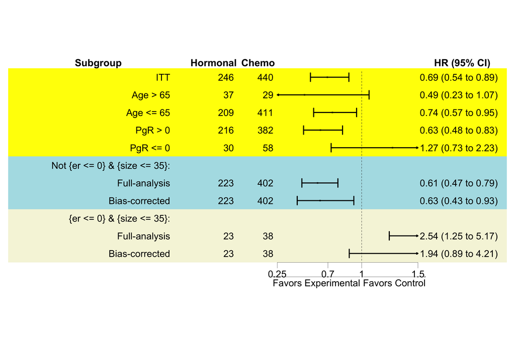

Subgroup forest plot including identified subgroups

```r
# Render forest plot
render_forestplot(result)
```

### 9.1.1 KM Difference Plots: ITT and Subgroups

The solid black line denotes the ITT Kaplan-Meier treatment difference estimates along with 95% CIs (the grey shaded region). K-M differences corresponding to subgroups are displayed.

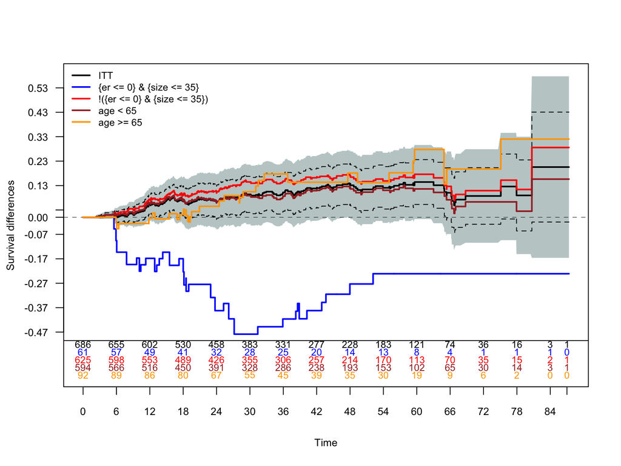

```r
# Add additional subgroups along with ITT and identified subgroups
ref_sgs <- list(
  age_young = list(subset_expr = "age < 65", color = "brown"),
  age_old = list(subset_expr = "age >= 65", color = "orange")
)

plot_km_band_forestsearch(
  df = df.analysis,
  fs.est = fs,
  ref_subgroups = ref_sgs,
  outcome.name = outcome.name,
  event.name = event.name,
  treat.name = treat.name,
  draws_band = 20
)
```

# 10 Summary and Interpretation

## 10.1 Key Findings

```r
cat(strrep("=", 60), "\n")
cat("FORESTSEARCH ANALYSIS SUMMARY\n")
```

```
#> FORESTSEARCH ANALYSIS SUMMARY
```

```r
cat(strrep("=", 60), "\n\n")
cat("Dataset: GBSG (N =", nrow(df.analysis), ")\n")
```

```
#> Dataset: GBSG (N = 686 )
```

```r
cat("Outcome: Recurrence-free survival\n\n")
```

```
#> Outcome: Recurrence-free survival
```

```r
cat("ITT Analysis:\n")
```

```
#> ITT Analysis:
```

```r
cat("  HR (95% CI): 0.69 (0.54, 0.89)\n\n")
```

```
#>   HR (95% CI): 0.69 (0.54, 0.89)
```

```r
cat("Identified Subgroup (H):\n")
```

```
#> Identified Subgroup (H):
```

```r
cat("  Definition:", paste(fs$sg.harm, collapse = " & "), "\n")
```

```
#>   Definition: {er <= 0} & {size <= 35}
```

```r
cat("  Size:", sum(fs$df.est$treat.recommend == 0),
    sprintf("(%.1f%%)\n", 100 * mean(fs$df.est$treat.recommend == 0)))
```

```
#>   Size: 61 (8.9%)
```

```r
cat("  Unadjusted HR:",
    sprintf("%.2f", exp(fs$grp.consistency$out_sg$result$hr[1])), "\n")
```

[output not shown]

```r
cat("\nComplement Subgroup (Hc):\n")
```

```
#>
#> Complement Subgroup (Hc):
```

```r
cat("  Size:", sum(fs$df.est$treat.recommend == 1),
    sprintf("(%.1f%%)\n", 100 * mean(fs$df.est$treat.recommend == 1)))
```

```
#>   Size: 625 (91.1%)
```

## 10.2 Clinical Interpretation

**Biological plausibility**: Tamoxifen is a selective estrogen receptor modulator. Its efficacy depends on ER expression. The finding that ER-negative patients may not benefit is consistent with:

- Mechanistic understanding of tamoxifen action
- Meta-analyses showing no tamoxifen benefit in ER-negative breast cancer
- Clinical guidelines recommending tamoxifen primarily for ER-positive tumors

**Caveats**:

1. This is an **exploratory** analysis requiring independent validation
2. The bias-corrected estimates have wider confidence intervals
3. Cross-validation metrics should be evaluated for algorithm stability

## 10.3 Computational Timing

```r
timings$total <- (proc.time() - t_vignette_start)["elapsed"]

timing_df <- data.frame(
  Analysis = c("GRF", "ForestSearch", "Bootstrap",
               "FS (DINA screening)", "DINA (standalone)",
               "FS (subgroup_method=dina)", "FS DINA bootstrap",
               "kfold", "oob", "Total"),
  Seconds = c(
    timings$grf,
    timings$forestsearch,
    timings$bootstrap,
    timings$fs_dina_screen,
    timings$dina_standalone,
    timings$fs_dina_select,
    timings$fs_dina_bootstrap,
    timings$kfold,
    timings$oob,
    timings$total
  )
)
timing_df$Minutes <- timing_df$Seconds / 60

gt(timing_df) |>
  tab_header(title = "Computational Timing") |>
  fmt_number(columns = c(Seconds, Minutes), decimals = 1) |>
  cols_label(
    Analysis = "Component",
    Seconds = "Time (sec)",
    Minutes = "Time (min)"
  )
```

Computational Timing

| Component | Time (sec) | Time (min) |
| --- | --- | --- |
| GRF | 0.3 | 0.0 |
| ForestSearch | 7.0 | 0.1 |
| Bootstrap | 754.9 | 12.6 |
| FS (DINA screening) | 4.2 | 0.1 |
| DINA (standalone) | 0.0 | 0.0 |
| FS (subgroup_method=dina) | 0.3 | 0.0 |
| FS DINA bootstrap | 83.4 | 1.4 |
| kfold | NA | NA |
| oob | NA | NA |
| Total | 1,098.3 | 18.3 |

# 11 References

León LF, Jemielita T, Guo Z, Marceau West R, Anderson KM (2024). “Exploratory subgroup identification in the heterogeneous Cox model: A relatively simple procedure.” *Statistics in Medicine*. DOI: 10.1002/sim.10163

# 13 Reproducibility payload (Section 6.2)

The chunk below harvests the already-computed objects from the three engine runs into one small list and writes it as an `.rds` for the manuscript Section 6.2 reader document to reproduce the table and the results overview. No analysis is repeated; the output path, core count, and package version resolve at run time.

```
#> Wrote Section 6.2 payload to: /Users/larryleon/Documents/GitHub/forestsearch/quarto/applications/gbsg/gbsg_table2A_payload.rds
```